# NPS IMD Intro to R

## NPS Inventory and Monitoring Division Intro to R Training: January 31 – February 2, 2022

## Installing required software

The only thing you really need to do to prepare for R training is to install the latest version of R and RStudio. We’ll talk about the difference between R and RStudio on the first day, but for now, just make sure they’re installed. Directions for installing R/RStudio are below. If you run into any problems, check the instructions at R for Data Science [Section 1.4.1 and 1.4.2](https://r4ds.had.co.nz/introduction.html#prerequisites).

**NOTE: If you don’t have Administrative privileges on your computer, you will have to submit an [IT HelpDesk Ticket](https://npshelpdesk.nps.gov/) (need to be on VPN or NPS network to access this link) to install R and RStudio, which could take a while. PLEASE PLAN AHEAD!**

Even if you already have R or RStudio installed, please install the latest versions of both programs. R recently went through a major version change from 3.x to 4.x with some potential code-breaking changes. The latest versions are needed to ensure everyone’s code behaves the same way.

**Install the latest version of R (4.1.2 as of January 2022)**

Assuming you’re on a PC, the installer for the latest version of R can be downloaded from [The Comprehensive R Archive Network (CRAN)](https://cran.r-project.org/bin/windows/base/). You’ll want to download the R installer by clicking on “Download R 4.0.4 for Windows”, or whatever the latest version number happens to be. After it downloads, open and run the installer with default settings. Note that there’s no need to pin R to your taskbar or add a shortcut to your desktop. For 99% of your needs, you’ll run R within RStudio, and won’t ever open R directly.

**Install RStudio**

The installer for RStudio for PCs can be downloaded [here](https://rstudio.com/products/rstudio/download/#download). You’ll need to click on the large blue “DOWNLOAD RSTUDIO FOR WINDOWS” button to download the installer. After it downloads, open and run the installer with default settings. I like having RStudio pinned to my taskbar, so it’s easier to find/open, but it’s up to you and your preferences.

**Install important libraries**

**Optional Reading**

We know you’re all busy and have to prioritize how you spend your time. If you have any time before training starts, we highly recommend reading [Chapter 2: R basics and workflows](https://stat545.com/r-basics.html) in STAT545. This is an online book based on a graduate level statistics class that Jenny Bryan teaches and is turning into this book. She’s a stats professor turned senior programmer at RStudio, and I really like how she approaches programming R in this book.

**Structure of training**

For most of the training, the trainer will share their screen to walk through the website and code. It will help a lot if you have 2 monitors, so you can have the screen being shared on one monitor and your own session of RStudio open on the other.

### Day 1: Intro to R

#### Intro to R & RStudio

##### Some Notes on Coding

Welcome to the class!

Learning (or re-learning) how to program can feel like an intimidating learning curve. Congrats on taking the first step! Before we delve into technical topics, let’s talk a little about coding in general.

##### It’s okay to make mistakes

Errors and broken code are not only part of the learning process, they’re part of the coding process. If you think your code is running perfectly on the first try, you probably didn’t test it thoroughly enough. It can be frustrating and discouraging when you can’t get your code to work the way you want it to, but getting stuck doesn’t make you a bad programmer. Try to approach broken code as a puzzle and a learning opportunity.

##### Use the resources available to you

As the saying goes,

> Good coders write good code; great coders steal great code.

Google and Stack Overflow are great resources when you don’t know off the top of your head how to do something. And reach out to your colleagues too - there’s no reason to waste time writing code that someone else has already written! Just give credit where credit is due, and take some time to make sure you understand what the copied code does. And especially don’t hesitate to reach out to more experienced colleagues with questions.

##### About R

R is a programming language that was originally developed by statisticians for statistical computing and graphics. R is free and open source, which means you will never need a paid license to use it, and anyone who wants to can view the underlying source code and suggest fixes and improvements. Since its first official release in 1995, R remains one of the leading programming languages for statistics and data visualization, and its capabilities continue to grow.

Every programming language has strengths and weaknesses. We like R because:

- It is great for statistics and data exploration
- It is good at producing publication-quality plots and tables
- There are many well-maintained add-ons (called *packages*) that add useful features to R (this website was built using the `rmarkdown` package)
- R is well-documented, with many learning resources available whether you are a beginner or an advanced user

For more information on the history of R, visit the [R Project website](https://www.r-project.org/about.html).

##### About RStudio

RStudio is what’s called an *integrated development environment* (IDE). When you install R, it comes with a simple user interface that lets you write and execute code. Writing code in this interface is kind of like doing word processing in Notepad: it’s simple and straightforward, but soon you’ll start wishing for more features. This is where RStudio comes in. RStudio makes programming in R easier by color coding different types of code, autocompleting code, flagging mistakes (like spellcheck for code), and providing many useful tools with the push of a button or key stroke (e.g. viewing help info).

When you open RStudio, you typically see 4 panes:

[figure not shown]

RStudio

- **Source:**  
  This is where the code gets written. When you create a new script or open an existing one, it displays here. In the screenshot above, there’s a script called bat_data_wrangling.R open in the source pane. Note that if you haven’t yet opened or created a new script, you won’t see this pane until you do.  
  The source pane will helpfully color-code your code to make it easier to read. It will also detect syntax errors (the coding equivalent of a grammar checker). These are flagged with a red “x” next to the line number and a squiggly line under the offending code. When you’re ready to run all or part of your script:
  - Highlight the line(s) of code you want to run
  - Either click the “Run” button (top right of the source pane) or press **Ctrl+Enter**. At this point, the code gets sent to the console (the bottom left pane). You’ll see your code appear in the console, and then you’ll see the output if there is any.
- **Console:**  
  This is where the code actually runs. When you first open RStudio, the console will tell you the version of R that you’re running (should be R 4.1.0 or greater). We talked above about how you can run a script at the console. You can also type code directly into the console and run it that way. That code won’t get saved to a file, but it’s a great way to experiment and test out lines of code before you add them to your script in the source pane.  
  The console is also where errors appear if your code breaks. Deciphering errors can be a challenge sometimes, but Googling them is a good place to start.
- **Environment/History/Connections:**
  - **Environment:** This is where you can see what is currently in your *environment*. Think of the environment as temporary storage for objects - things like datasets and stored values - that you are using in your script(s). You can also click on objects and view them.  
    Remember that anything you see in your environment is temporary and it will disappear when you restart R. If there is something in your environment that you want to access in the future, make sure that your script is able to reproduce it (or save it to a file).
  - **History:** This shows the code you’ve run in the current session. It’s not good to rely on it, but it can be a way to recover code you ran at the console and later realized you needed in your script.
  - **Connections:** This is one way to connect R to a database. We’ll talk about this more later on.
  - **Git:** If you have installed Git on your computer, you may see a *Git* tab. We won’t talk much about it this week, but this is where you’ll keep track of changes to your code. You are encouraged to attend the Git/GitHub session during Week 2 if you’d like to learn more!
  - **Tutorial:** This has some interactive tutorials that you can check out if you are interested.
- **Files/Plots/Packages/Help/Viewer:**
  - **Files:** This tab shows the files within your working directory (typically the folder where your current code project lives). More on this later.
  - **Plots:** This tab will show plots that you create.
  - **Packages:** This tab allows you to install, load, and update packages, and also view the help files within each package. This is kind of like the R equivalent of an app store. You can also do this with code.
  - **Help:** Allows you to search for and view documentation for packages that are installed on your computer.
  - **Viewer:** Shows HTML outputs produced by R Markdown, R Shiny, and some plotting and mapping packages.

##### Global Options

There are several settings in the Global Options that everyone should check to make sure we all have consistent settings. Go to **Tools -> Global Options** and follow the steps below.

1. Under the General tab, you should see that your R Version is [64-bit] and the version is R-4.1.0 or greater. If it’s not, you probably need to update R. Let an instructor know if you have questions about this.
2. Make sure you are not saving your environment. To do this, **uncheck** the **Restore .RData into your workspace at startup** option.  
   When this option is checked, R Studio saves your current working environment (the stuff in the Environment tab) when you exit. The next time you open R Studio, it restores that same environment. This seems like a good thing, but the whole point of using R is that your code should return the same results every time you run it. Clearing your environment every time you close RStudio forces you to run your code with a clean slate so that you can be sure that it will work for everyone, not just you and your specific environment.  
   If you sometimes work with huge datasets that take a long time to load and process, you may want to set **Save workspace to .RData on exit** to “Ask”. When you close RStudio, it will ask you if you want to save your workspace image. If you have a huge dataset (or the products of a huge dataset) in your environment, select “Yes” and then run `load(".RData")` at the console the next time you open RStudio to restore everything.

Most other settings are whatever you prefer, including everything in the Appearance window.

##### Starting a Project

When you’re working on a code project it’s important to stay organized. Keeping code, input data, and results together in one place will protect your sanity and the sanity of the person who inherits the project. R Studio **projects** help with this. Creating a new R Studio project for each new code project makes it easier to manage settings and file paths.

Before we create a project, take a look at the **Console** tab. Notice that at the top of the console there is a folder path. That path is your current working directory.

[figure not shown]

default working directory

If you refer to a file in R using a *relative path*, for example `./data/my_data_file.csv`, R will look in your current working directory for a folder called `data` containing a file called `my_data_file.csv`. Using relative paths is a good idea because the full path is specific to your computer and likely won’t work on a different computer. But there’s no guarantee that everyone has the same default R working directory. This is where projects come in.  
Let’s make a project for this class. Click **File > New Project**. In the window that appears, select **New Directory**, then select **New Project**. You will be prompted for a directory name. This is the name of your project folder. For this class, call it `imd-r-training-intro`. Next, you’ll select what folder to keep your project folder in. `Documents/R` is a good place to store all of your R projects but it’s up to you. When you are done, click on **Create Project**.

[figure not shown]

[figure not shown]

[figure not shown]

If you successfully started a project named `imd-r-training-intro`, you should see it listed at the very top right of your screen. As you start new projects, you’ll want to check that you’re working in the right one before you start coding. Take a look at the **Console** tab again. Notice that your current working directory is now your project folder. When you look in the **Files** tab of the bottom right pane, you’ll see that it also defaults to the project folder.

#### Let’s start coding

First we need to create a new R script file. Make sure you are working in the `imd-r-training-intro` project that you just created. Click on the **New File** icon in the top left corner. In the dropdown, select **R Script**. The source pane will appear with an untitled empty script. Go ahead and save it by clicking the **Save** icon (and make sure the **Source on Save** checkbox is deselected). Call it `my_first_script.R`.

##### The basics

We’ll start with something simple. Basic math in R is pretty straightforward and the syntax is similar to simply using a graphing calculator. Try it out! You can use the examples below or come up with your own. Even if you’re using the examples, try to actually type the code instead of copy-pasting - you’ll learn to code faster that way.

To run a single line of code in your script, place your cursor anywhere in that line and press CTRL+ENTER (or click the **Run** button in the top right of the script pane). To run multiple lines of code, highlight the lines you want to run and hit CTRL+ENTER or click **Run**.

Text following a hashtag/pound sign (#) will be ignored - use this to leave comments about what your code is doing. Commenting your code is one of the best habits you can form, and you should start now! Comments are a gift to your future self and anyone else who tries to use your code.

```r
# By using this hashtag/pound sign, you are telling R to ignore the text afterwards. This is useful for leaving annotation of notes or instructions for yourself, or someone else using your code

# try this line to generate some basic text and become familiar with where results will appear:
print("Hello, lets do some basic math. Results of operations will appear here")
```

```
## [1] "Hello, lets do some basic math. Results of operations will appear here"
```

```r
# one plus one
1+1
```

```
## [1] 2
```

```r
# two times three, divided by four
(2*3)/4
```

```
## [1] 1.5
```

```r
# basic mathematical and trigonometric functions are fairly similar to what they would be in excel

# calculate the square root of 9
sqrt(9)
```

```
## [1] 3
```

```r
# calculate the cube root of 8 (remember that x^(1/n) gives you the nth root of x)
8^(1/3)
```

```
## [1] 2
```

```r
# get the cosine of 180 degrees - note that trig functions in R expect angles in radians
# also note that pi is a built-in constant in R
cos(pi)
```

```
## [1] -1
```

```r
# calculate 5 to the tenth power
5^10
```

```
## [1] 9765625
```

Notice that when you run a line of code, the code and the result appear in the console. You can also type code directly into the console, but it won’t be saved anywhere. As you get more comfortable with R, it can be helpful to use the console as a “scratchpad” for experimenting and troubleshooting. For now, it’s best to err on the side of saving your code as a script so that you don’t accidentally lose useful work.

#### Variables and functions

##### Variables

Occasionally, it’s enough to just run a line of code and display the result in the console. But typically the code we write is more complex than adding one plus one, and when we execute a line of code, we want to be able to store the result and use it later in the script. This is where variables come in. Variables allow you to assign a value (whether that’s a number, a data table, a chunk of text, or any other type of data that R can handle) to a short, human-readable name. Anywhere you put a variable in your code, R will replace it with its value when your code runs.

R uses the `<-` symbol for variable assignment. If you’ve used other programming languages (or remember high school algebra), you may be tempted to use `=` instead. It will work, but there are subtle differences between `<-` and `=`, so you should get in the habit of using `<-`.

```r
# the value of 12.098 is assigned to variable 'a'
a <- 12.098

# and the value 65.3475 is assigned to variable 'b'
b <- 65.3475

# we can now perform whatever mathematical operations we want using these two variables without having to repeatedly type out the actual numbers:

a*b
```

```
## [1] 790.5741
```

```r
(a^b)/((b+a))
```

```
## [1] 7.305156e+68
```

```r
sqrt((a^7)/(b*2))
```

```
## [1] 538.7261
```

In the code above, we assign the variables `a` and `b` once. We can then reuse them as often as we want. This is helpful because we save ourselves some typing, reduce the chances of making a typo somewhere, and if we need to change the value of `a` or `b`, we only have to do it in one place.

Also notice that when you assign variables, you can see them listed in your Environment tab (top right pane). Remember, everything you see in the environment is just in R’s temporary memory and won’t be saved when you close out of RStudio.

All of the examples you’ve seen so far are fairly contrived for the sake of simplicity. Let’s take a look at some code that everyone here will make use of at some point: reading data from a CSV.

##### Functions

It’s hard to get very far in R without making use of *functions.* Think of a function as a black box that takes some kind of input (the *argument(s)*) from the user and outputs a result (the *return value*). Can you identify the functions in the above examples?

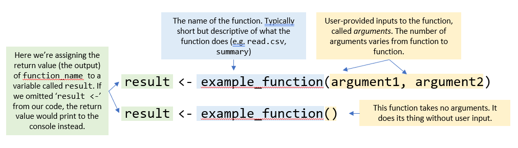

anatomy of a function

##### Using functions - reading data from CSV

The read.csv function is used to bring in a dataset from a CSV file, and it stores the data in one of the fundamental data structures in R: a data frame. `read.csv()` takes the file path to the CSV as input, and it outputs a data frame containing the data from the CSV.

We’ll get very familiar with data frames in this class, but for the moment just know that it’s a table of data with rows and columns. Data frames are typically organized with rows being records or observations (e.g. sampling locations, individual critters, etc.), and columns being variables that characterize those observations (e.g., species, size, date collected, x/Y coordinates). Once you have read the data in, you can take a quick look at its structure by typing the name of the variable it’s stored in.

```r
# read in the data from tree_growth.csv and assign it as a dataframe to the variable "tree_data"
tree_data <- read.csv("data/tree_growth.csv")

# display the 'tree_data' data frame we just created
tree_data
```

```
##               Species DBH_in Height_ft Age_yr
## 1   arboreas madeupis    4.0         6      3
## 2   arboreas madeupis    6.0        10      5
## 3   arboreas madeupis    8.0         5      6
## 4   arboreas madeupis   11.0         7      6
## 5   arboreas madeupis   12.0        16      8
## 6   arboreas madeupis   13.0        19      8
## 7   arboreas madeupis   12.0        24     11
## 8   arboreas madeupis   20.0        22     11
## 9   arboreas madeupis   20.0        32     12
## 10  arboreas madeupis   11.0        31     13
## 11  arboreas madeupis   27.0        35     15
## 12  arboreas madeupis   25.0        33     15
## 13  arboreas madeupis   30.0        40     17
## 14  arboreas madeupis   35.0        67     18
```

[output cut: 29 more lines]

#### Examining datasets

Compared to scrolling through a dataset in Excel, examining a dataset in R can feel unintuitive at first. Stick with it, though. Once you get used to exploring data in R, you’ll find that R will help you learn more about your dataset in a more efficient manner.

Let’s see what we can learn about the dataset as a whole. The most useful functions for this are: - `head()` Show only the first few lines of the dataframe in the console. The function is useful for taking a quick glance to ensure that column names were properly assigned, and to take a quick look a column names without printing the whole dataset. - `summary()` Show a basic statistical summary of the dataset. - `str()` Show information about the structure of the dataset, including number of rows and columns, column data types, and the first few values in each column. - `View()` In a new tab, display a spreadsheet-like view of the full dataset with options to sort and filter. Note that you can’t change the data in this view - it is read-only.

```r
head(tree_data)  # Show the first few lines of the dataframe. Defaults to showing the first 6 rows
```

```
##             Species DBH_in Height_ft Age_yr
## 1 arboreas madeupis      4         6      3
## 2 arboreas madeupis      6        10      5
## 3 arboreas madeupis      8         5      6
## 4 arboreas madeupis     11         7      6
## 5 arboreas madeupis     12        16      8
## 6 arboreas madeupis     13        19      8
```

```r
head(tree_data, n = 10)  # Show the first 10 rows
```

```
##              Species DBH_in Height_ft Age_yr
## 1  arboreas madeupis      4         6      3
## 2  arboreas madeupis      6        10      5
## 3  arboreas madeupis      8         5      6
## 4  arboreas madeupis     11         7      6
## 5  arboreas madeupis     12        16      8
## 6  arboreas madeupis     13        19      8
## 7  arboreas madeupis     12        24     11
## 8  arboreas madeupis     20        22     11
## 9  arboreas madeupis     20        32     12
## 10 arboreas madeupis     11        31     13
```

```r
summary(tree_data)  # View a basic statistical summary
```

```
##    Species              DBH_in        Height_ft          Age_yr
##  Length:43          Min.   : 4.00   Min.   :  5.00   Min.   : 2.00
##  Class :character   1st Qu.:11.00   1st Qu.: 12.50   1st Qu.: 7.50
##  Mode  :character   Median :12.60   Median : 23.00   Median :15.00
##                     Mean   :24.78   Mean   : 35.35   Mean   :18.81
##                     3rd Qu.:30.50   3rd Qu.: 62.50   3rd Qu.:25.50
##                     Max.   :99.00   Max.   :100.00   Max.   :61.00
```

```r
str(tree_data)  # Get info about the structure of the data
```

```
## 'data.frame':    43 obs. of  4 variables:
##  $ Species  : chr  "arboreas madeupis" "arboreas madeupis" "arboreas madeupis" "arboreas madeupis" ...
##  $ DBH_in   : num  4 6 8 11 12 13 12 20 20 11 ...
##  $ Height_ft: int  6 10 5 7 16 19 24 22 32 31 ...
##  $ Age_yr   : int  3 5 6 6 8 8 11 11 12 13 ...
```

```r
View(tree_data)  # Open a new tab with a spreadsheet view of the data
```

#### Data structures

We’re going to take a little detour into data structures at this point. It’ll all tie back in to our tree data.

The data frame we just examined is a type of data structure. A data structure is what it sounds like: it’s a structure that holds data in an organized way. There are multiple data structures in R, including vectors, lists, arrays, matrices, data frames, and tibbles (more on this unfortunately-named data structure later). Today we’ll focus on vectors and data frames.

##### Vectors

Vectors are the simplest data structure in R. You can think of vectors as one column of data in an Excel spreadsheet, and the elements are each row in the column. Here are some examples of vectors:

```r
digits <- 0:9  # Use x:y to create a sequence of integers starting at x and ending at y
digits
```

```
##  [1] 0 1 2 3 4 5 6 7 8 9
```

```r
is_odd <- rep(c(FALSE, TRUE), 5)  # Use rep(x, n) to create a vector by repeating x n times
is_odd
```

```
##  [1] FALSE  TRUE FALSE  TRUE FALSE  TRUE FALSE  TRUE FALSE  TRUE
```

```r
shoe_sizes <- c(7, 7.5, 8, 8.5, 9, 9.5, 10, 10.5, 11, 11.5)
shoe_sizes
```

```
##  [1]  7.0  7.5  8.0  8.5  9.0  9.5 10.0 10.5 11.0 11.5
```

```r
favorite_birds <- c("greater roadrunner", "Costa's hummingbird", "kakapo")
favorite_birds
```

```
## [1] "greater roadrunner"  "Costa's hummingbird" "kakapo"
```

Note the use of `c()`. The `c()` function stands for *combine*, and it combines elements into a single vector. The c() function is a fairly universal way to combine multiple elements in R, and you’re going to see it over and over.

Let’s play around with vectors a little more. We can use `is.vector()` to test whether something is a vector. We can get the length of a vector with `length()`. Note that single values in R are just vectors of length one.

```r
is.vector(digits)  # Should be TRUE
```

```
## [1] TRUE
```

```r
is.vector(favorite_birds)  # Should also be TRUE
```

```
## [1] TRUE
```

```r
length(digits)  # Hopefully this is 10
```

```
## [1] 10
```

```r
length(shoe_sizes)
```

```
## [1] 10
```

```r
# Even single values in R are stored as vectors
length_one_chr <- "length one vector"
length_one_int <- 4
is.vector(length_one_chr)
```

```
## [1] TRUE
```

```r
is.vector(length_one_int)
```

```
## [1] TRUE
```

```r
length(length_one_chr)
```

```
## [1] 1
```

```r
length(length_one_int)
```

```
## [1] 1
```

In the examples above, each vector contains a different type of data. `digits` contains integers, `is_odd` contains logical (true/false) values, `favorite_birds` contains text, and shoe_sizes contains decimal numbers. That’s because a given vector can only contain a single type of data. In R, there are four *data types* that we will typically encounter:

- **character** Regular text, denoted with double or single quotation marks (e.g. `"hello"`, `"3"`, `"R is my favorite programming language"`)
- **numeric** Decimal numbers (e.g. `23`, `3.1415`)
- **integer** Integers. If you want to explicitly denote a number as an integer in R, append `L` to it or use `as.integer()` (e.g. `5L`, `as.integer(30)`).
- **logical** True or false values (`TRUE`, `FALSE`). Note that `TRUE` and `FALSE` must be all-uppercase.

There are two more data types, complex and raw, but you are unlikely to encounter these so we won’t cover them here.

You can use the `class()` function to get the data type of a vector:

```r
class(favorite_birds)
```

```
## [1] "character"
```

```r
class(shoe_sizes)
```

```
## [1] "numeric"
```

```r
class(digits)
```

```
## [1] "integer"
```

```r
class(is_odd)
```

```
## [1] "logical"
```

If you need to access a single element of a vector, you can use the syntax `my_vector[x]` where `x` is the element’s *index* (the number corresponding to its position in the vector). You can also use a vector of indices to extract multiple elements from the vector. Note that in R, indexing starts at 1 (i.e. `my_vector[1]` is the first element of `my_vector`). If you’ve coded in other languages, you may be used to indexing starting at 0.

```r
second_favorite_bird <- favorite_birds[2]
second_favorite_bird
```

```
## [1] "Costa's hummingbird"
```

```r
top_two_birds <- favorite_birds[c(1,2)]
top_two_birds
```

```
## [1] "greater roadrunner"  "Costa's hummingbird"
```

Logical vectors can also be used to subset a vector. The logical vector must be the length of the vector you are subsetting.

```r
odd_digits <- digits[is_odd]
odd_digits
```

```
## [1] 1 3 5 7 9
```

##### Data frames

Let’s revisit our trees data frame. We’ve explored the data frame as a whole, but it’s often useful to look at one column at a time. To do this, we’ll use the `$` syntax:

```r
tree_data$Species
```

```
##  [1] "arboreas madeupis"  "arboreas madeupis"  "arboreas madeupis"
##  [4] "arboreas madeupis"  "arboreas madeupis"  "arboreas madeupis"
##  [7] "arboreas madeupis"  "arboreas madeupis"  "arboreas madeupis"
## [10] "arboreas madeupis"  "arboreas madeupis"  "arboreas madeupis"
## [13] "arboreas madeupis"  "arboreas madeupis"  "arboreas madeupis"
## [16] "arboreas madeupis"  "arboreas madeupis"  "arboreas madeupis"
## [19] "arboreas madeupis"  "arboreas madeupis"  "arboreas madeupis"
## [22] "arboreas madeupis"  "arboreas madeupis"  "arboreas madeupis"
## [25] "arboreas madeupis"  "planteus falsinius" "planteus falsinius"
## [28] "planteus falsinius" "planteus falsinius" "planteus falsinius"
## [31] "planteus falsinius" "planteus falsinius" "planteus falsinius"
## [34] "planteus falsinius" "planteus falsinius" "planteus falsinius"
## [37] "planteus falsinius" "planteus falsinius" "planteus falsinius"
## [40] "planteus falsinius" "planteus falsinius" "planteus falsinius"
## [43] "planteus falsinius"
```

```r
tree_data$Age_yr
```

```
##  [1]  3  5  6  6  8  8 11 11 12 13 15 15 17 18 21 30 32 36 37 38 40 43 51 55 61
## [26]  2  4  5  4  6  8  7  7  9 12 15 17 18 15 17 21 20 30
```

You can also use square brackets `[]` to access data frame columns. You can specify columns by name or by index (integer indicating position of column). It’s almost always best to refer to columns by name when possible - it makes your code easier to read, and it prevents your code from breaking if columns get reordered.

The square bracket syntax allows you to select multiple columns at a time and to select a subset of rows.

```r
tree_data[, "Species"]  # Same as tree_data$Species
```

```
##  [1] "arboreas madeupis"  "arboreas madeupis"  "arboreas madeupis"
##  [4] "arboreas madeupis"  "arboreas madeupis"  "arboreas madeupis"
##  [7] "arboreas madeupis"  "arboreas madeupis"  "arboreas madeupis"
## [10] "arboreas madeupis"  "arboreas madeupis"  "arboreas madeupis"
## [13] "arboreas madeupis"  "arboreas madeupis"  "arboreas madeupis"
## [16] "arboreas madeupis"  "arboreas madeupis"  "arboreas madeupis"
## [19] "arboreas madeupis"  "arboreas madeupis"  "arboreas madeupis"
## [22] "arboreas madeupis"  "arboreas madeupis"  "arboreas madeupis"
## [25] "arboreas madeupis"  "planteus falsinius" "planteus falsinius"
## [28] "planteus falsinius" "planteus falsinius" "planteus falsinius"
## [31] "planteus falsinius" "planteus falsinius" "planteus falsinius"
## [34] "planteus falsinius" "planteus falsinius" "planteus falsinius"
## [37] "planteus falsinius" "planteus falsinius" "planteus falsinius"
## [40] "planteus falsinius" "planteus falsinius" "planteus falsinius"
## [43] "planteus falsinius"
```

```r
tree_data[, c("Species", "Age_yr")]  # Data frame with only Species and Age_yr columns
```

```
##               Species Age_yr
## 1   arboreas madeupis      3
## 2   arboreas madeupis      5
## 3   arboreas madeupis      6
## 4   arboreas madeupis      6
## 5   arboreas madeupis      8
## 6   arboreas madeupis      8
## 7   arboreas madeupis     11
## 8   arboreas madeupis     11
## 9   arboreas madeupis     12
## 10  arboreas madeupis     13
## 11  arboreas madeupis     15
## 12  arboreas madeupis     15
## 13  arboreas madeupis     17
## 14  arboreas madeupis     18
```

[output cut: 29 more lines]

```r
tree_data[1:5, "Species"]  # First five elements of Species column
```

```
## [1] "arboreas madeupis" "arboreas madeupis" "arboreas madeupis"
## [4] "arboreas madeupis" "arboreas madeupis"
```

Now that we’ve learned about vectors, these data frame columns might look familiar. A data frame is just a collection of vectors of the same length, where each vector is a column.

```r
is.vector(tree_data$Species)
```

```
## [1] TRUE
```

```r
class(tree_data$Species)
```

```
## [1] "character"
```

```r
is.vector(tree_data$Age_yr)
```

```
## [1] TRUE
```

```r
class(tree_data$Age_yr)
```

```
## [1] "integer"
```

```r
str(tree_data)  # Check out the abbreviations next to the column names: chr, num, and int. These are the data types of the columns.
```

```
## 'data.frame':    43 obs. of  4 variables:
##  $ Species  : chr  "arboreas madeupis" "arboreas madeupis" "arboreas madeupis" "arboreas madeupis" ...
##  $ DBH_in   : num  4 6 8 11 12 13 12 20 20 11 ...
##  $ Height_ft: int  6 10 5 7 16 19 24 22 32 31 ...
##  $ Age_yr   : int  3 5 6 6 8 8 11 11 12 13 ...
```

#### Working with columns

R is great at working with vectors because they are the fundamental data structure of the language. Since data frame columns are vectors, they are typically easy to operate on.

Basic statistical summary functions aren’t too different from what you’d do in Excel.

```r
#to calculate the mean of the 'age' column in the original dataframe:
mean(tree_data$Age_yr)
```

```
## [1] 18.81395
```

```r
#or to calculate the mean of the DBH vector we created:
dbh <- tree_data$DBH_in
mean(dbh)
```

```
## [1] 24.78372
```

```r
#like-wise for the median, standard deviation, and minimum:
median(tree_data$Age_yr)
```

```
## [1] 15
```

```r
sd(tree_data$Age_yr)
```

```
## [1] 15.02261
```

```r
min(tree_data$Age_yr)
```

```
## [1] 2
```

Another useful way to summarize a column is to get the unique values it contains. This is typically most useful with character columns (e.g. species) but works with any data type.

```r
unique(tree_data$Species)  # in this line, we are printing all of the unique species names in the dataset (in this case 2).
```

```
## [1] "arboreas madeupis"  "planteus falsinius"
```

```r
species_names <- unique(tree_data$Species)  # assign unique species names to a variable
```

Summarizing data is useful but we also want to be able to modify it. So let’s say we want to convert the ‘Height_ft’ column in `tree_data` from feet to inches. We’ll start by assigning a conversion factor to the variable `in_per_ft`.

```r
in_per_ft <- 12  # Since there are 12 inches in a foot
```

We can then use this conversion factor to convert the ‘Height_ft’ column to inches, and place this converted value in a new column we will create in the data frame. Notice below that if you assign a vector to a column that doesn’t exist yet, R will automatically create that column. We’ll use the `head()` function to verify that the `Height_in` column was created correctly.

```r
# here we are specifying the new column on the left side of the '<-', and telling R what we want put into it on the right side of the '<-'.
tree_data$Height_in <- tree_data$Height_ft * in_per_ft

# we can now use the 'head function to check our work, and make sure the proper conversion was carried out:
head(tree_data)
```

```
##             Species DBH_in Height_ft Age_yr Height_in
## 1 arboreas madeupis      4         6      3        72
## 2 arboreas madeupis      6        10      5       120
## 3 arboreas madeupis      8         5      6        60
## 4 arboreas madeupis     11         7      6        84
## 5 arboreas madeupis     12        16      8       192
## 6 arboreas madeupis     13        19      8       228
```

#### Basic data visualization

It’s often easier to get a sense of our data by visualizing it, so let’s explore the basic tools for taking a first glance at our data.

##### Histogram

We’ll start with a histogram. The code below generates a basic histogram plot of a specific column in the dataframe (remember from earlier that this is denoted by the `$` sign) using the `hist()` function. We’ll start by creating a histogram for the ‘Age_yr’ column.

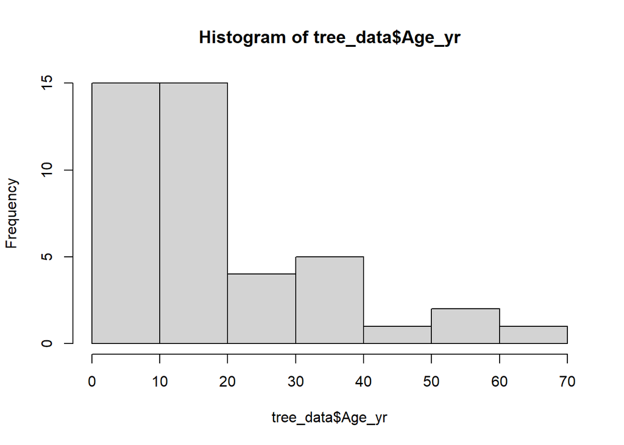

```r
hist(x = tree_data$Age_yr)
```

Looking at the histogram, we can see that the age of most trees in the dataset fall in the 0-20 year old age class.

##### Scatter plot

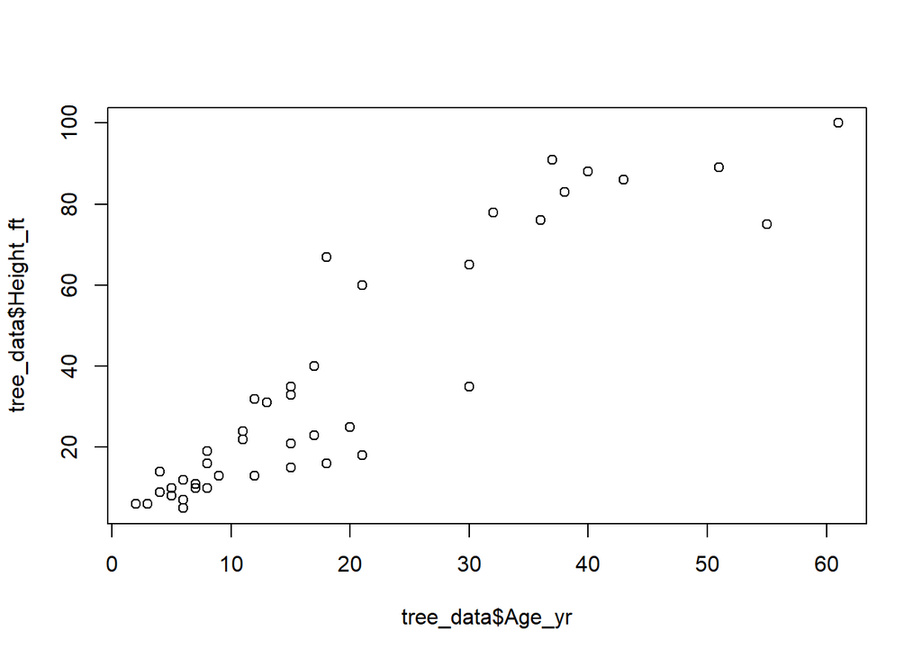

```r
# this should generate an ugly but effective scatterplot of tree height vs age. It would appear that older trees are taller!
plot(x = tree_data$Age_yr, y = tree_data$Height_ft)
```

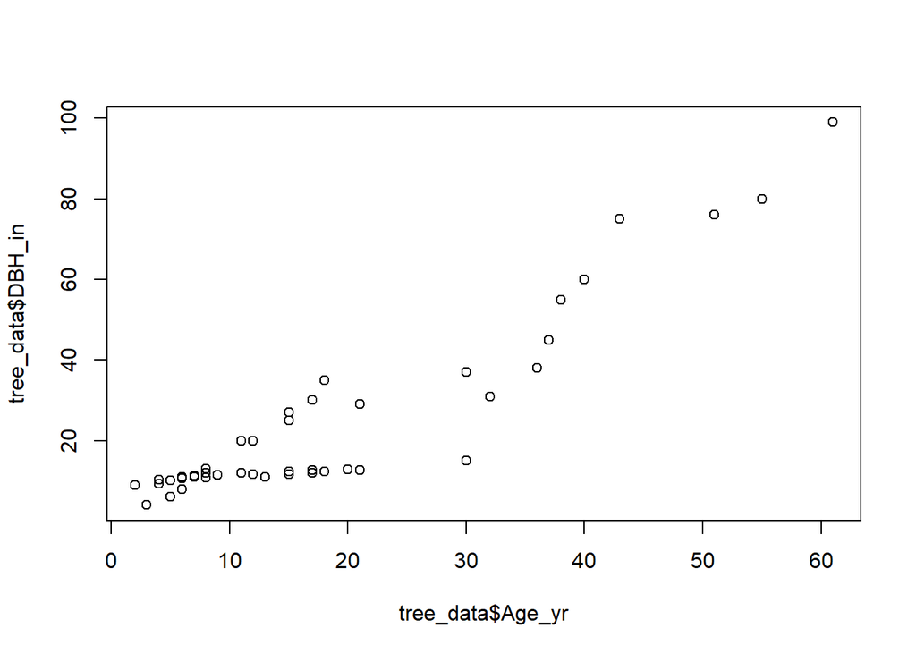

```r
# let's try the same, but with DBH as the dependent variable on the y axis:
# again, we should see a plot below showing that, even in a make-believe forest, older trees of both species tend to be thicker!
plot(x = tree_data$Age_yr, y = tree_data$DBH_in)
```

#### Getting Help

##### Getting Help

There are a number of options to get help with R. If you’re trying to figure out how to use a function, you can type ?function_name. For example *?plot* will show the R documentation for that function in the Help panel.

```r
?plot
?dplyr::filter
```

If you have a question, online resources include Stackexchange and Stackoverflow are extremely helpful. Google searches are a great first step. It helps to include “in R” in every search related to R code.

Don’t hesitate to reach out to colleagues for help as well! If you are stuck on something and the answers on Google are more confusing than helpful, don’t be afraid to ask a human. Every experienced R programmer was a beginner once, so chances are they’ve encountered the same problem as you at some point. There is an R-focused data science community of practice for I&M folks, which anyone working in R (regardless of experience!) is invited and encouraged to join. The Teams join code will be shared with course participants.

### Day 2: Data Wrangling

#### Intro to Data Wrangling - Intro and Packages

**Data Wrangling Intro**

Goals of this Day

1. Learn to load and understand how packages work
2. Understand what data wrangling is and some ways to do it.
3. Learn how to clean your import data so that R understands what it is
4. Get data in the format you need for analysis using the tidyverse.
5. Combine data from different data.frames so that it is in the correct format

**Disclaimer: While R provides lots of ways to check and clean up data, these tools are no replacement for sound data management that prevents data issues from happening in the first place.**

**Working with Packages: Installing a Package**

What is a package? A package is a group of functions that someone has put together. They come with documentation that tells you about what each function does.

First, load package

1. Go to packages tab in lower right quadrant
2. Click on “install”
3. Type name of package ‘janitor’
4. Click “install”
5. Code will pop up in your console

```r
install.packages("janitor")
```

**Calling a Package**

To use a package, call it by using the function “library”

```r
library('janitor')
```

This is called “loading a package” or “calling a package”.

**Using Package**

Look at the vignette

- Go to packages window of lower right quadrant
- Click on ‘janitor’ name in list of packages
- Vignette will show up in the ‘help’ tab

*take time to click a function from the vignette list* *walk through how to get helpful info*

Did you get “error” text?

Text pops up in the console after you run code You must decide whether it means you have to change something or not

```r
library('janitor')
```

**Challenge: Install a Package**

Challenge: install + call the package ‘tidyverse’

**Solution**

Solution: install + call the package ‘tidyverse’

```r
install.packages("tidyverse")
library('tidyverse')
```

#### Intro to Data Wrangling - Data Cleaing

**Data Cleaning**

Data wrangling is all the steps you have to take to prepare your data for analysis or plotting. Data munging or data cleaning are other terms used to describe this process.Material presented today can be found in Hadley Wickham’s book “R for Data Science”, which is free and online. https://r4ds.had.co.nz/wrangle-intro.html

If you’re starting from this tab of the lesson, you’ll need to load two packages before proceeding.

```r
library('janitor')
library('tidyverse')
```

Major Components to Data Wrangling

- Step 1: Import (covered yesterday)
- Step 2+3: Tidy & Transform (get data into a useful format)

**Column Names**

Sometimes you get data where the column names are messy. For an example of data that needs tidying before exploration and analyses, we’ll use fake data. Copy + paste the code chunk below into your script, and run it in the console to generate a dataframe called “messy_data”.

Here, we’ll clarify that we are using the word “data.frame” or “dataframe” to describe the data. The word “tibble” also shows up. We’ll use these terms interchangeably.

```r
messy_data <- tibble(TrailName = c('Bayside', 'Coastal', 'Tidepools',
                                   'Monument', 'Tidepools', NA),
                     Visitor_count = c(200, 300, 400, 500, 400, NA),
                     `empty row` = NA)
```

This data.frame captures the hypothetical number of visitors across four trails at a park. There are a few qualities that make it difficult to interpret. Seeing this data, what would you change to make it most consistent?

```r
messy_data
```

```
## # A tibble: 6 x 3
##   TrailName Visitor_count `empty row`
##   <chr>             <dbl> <lgl>
## 1 Bayside             200 NA
## 2 Coastal             300 NA
## 3 Tidepools           400 NA
## 4 Monument            500 NA
## 5 Tidepools           400 NA
## 6 <NA>                 NA NA
```

There are four things I suggest fixing with these data:

1. The column names are inconsistently formatted
2. There is an empty row
3. There is an empty column
4. There is a duplicated row

The Janitor package has ways to fix all of these data situations and aid in data cleaning. Let’s proceed with changing the column names.

The clean_names() function in the janitor package will consistently format column names.

```r
clean_data <- clean_names(messy_data)
clean_data
```

```
## # A tibble: 6 x 3
##   trail_name visitor_count empty_row
##   <chr>              <dbl> <lgl>
## 1 Bayside              200 NA
## 2 Coastal              300 NA
## 3 Tidepools            400 NA
## 4 Monument             500 NA
## 5 Tidepools            400 NA
## 6 <NA>                  NA NA
```

**Empty Rows and Columns**

Now, we’ll deal with the empty row and empty column. To remove empty rows or columns, we can use the remove_empty() function.

The arguments for the function are as follows:

```r
remove_empty(
  # first argument is the data
  dat,
  # the next specifies if you want to get rid of empty rows, columns, or both
  which = c("rows", "cols"),
  # this last one asks whether (TRUE) or not (FALSE) you want R to tell you which rows or columns were removed
  quiet = TRUE)
```

Let’s give it a try

Removing empty rows

```r
clean_data2 <- remove_empty(clean_data, which = c('rows'), quiet = FALSE)
```

```
## Removing 1 empty rows of 6 rows total (16.7%).
```

```r
clean_data2
```

```
## # A tibble: 5 x 3
##   trail_name visitor_count empty_row
##   <chr>              <dbl> <lgl>
## 1 Bayside              200 NA
## 2 Coastal              300 NA
## 3 Tidepools            400 NA
## 4 Monument             500 NA
## 5 Tidepools            400 NA
```

Removing empty rows and columns

```r
clean_data2 <- remove_empty(clean_data, which = c('rows', 'cols'), quiet = TRUE)
clean_data2
```

```
## # A tibble: 5 x 2
##   trail_name visitor_count
##   <chr>              <dbl>
## 1 Bayside              200
## 2 Coastal              300
## 3 Tidepools            400
## 4 Monument             500
## 5 Tidepools            400
```

**The Pipe - Sequences of Functions**

What happens if you’d like to both clean_names() and remove_empty() on the same data?

Solution 1 - run as a sequence

```r
clean_data <- clean_names(messy_data)
clean_data <- remove_empty(clean_data, which = c('rows', 'cols'), quiet = TRUE)
clean_data
```

```
## # A tibble: 5 x 2
##   trail_name visitor_count
##   <chr>              <dbl>
## 1 Bayside              200
## 2 Coastal              300
## 3 Tidepools            400
## 4 Monument             500
## 5 Tidepools            400
```

Solution 2 - use the pipe operator

Pipe operators (%>% or |>) can be read like the word “then”. For example, clean_names() %>% remove_empty() can be read as “clean names, then remove empty”. They allow for a more clean workflow.

```r
clean_data <- clean_names(messy_data) %>%
              remove_empty(which = c('rows', 'cols'), quiet = TRUE)
clean_data
```

```
## # A tibble: 5 x 2
##   trail_name visitor_count
##   <chr>              <dbl>
## 1 Bayside              200
## 2 Coastal              300
## 3 Tidepools            400
## 4 Monument             500
## 5 Tidepools            400
```

```r
# note that replacing %>% with |> also works
```

Note that there is no data argument in the remove_empty() function. This is because, when using a pipe, the data argument is inherited from the prior function.

**Removing Duplicate Entries**

A final function we’ll discuss is distinct() from the dplyr package, which is park of tidyverse. It removes duplicate rows from data.

```r
clean_data <- clean_names(messy_data) %>%
              remove_empty(which = c('rows', 'cols'), quiet = TRUE) %>%
              distinct()
clean_data
```

```
## # A tibble: 4 x 2
##   trail_name visitor_count
##   <chr>              <dbl>
## 1 Bayside              200
## 2 Coastal              300
## 3 Tidepools            400
## 4 Monument             500
```

A word of caution - sometimes you may not want to remove duplicate rows, or may not want to remove empty rows, because they are important to the data. You know your data best. Use functions responsibly.

**Challenge**

The code chunk below creates messy data, called “messy_data2”. Use functions from the Janitor package to tidy the data, and name the result “clean_data2”. See if you can use the pipe operator to streamline the script.

```r
messy_data2 <- tibble(`Park Code` = c(NA, NA, 'CABR', 'CHIS', 'SAMO', 'SAMO'),
                     visitor_count = c(NA, NA, 400, 500, 400, 400),
                     `empty row` = NA)
```

**Solution**

```r
clean_data2 <- clean_names(messy_data2) %>%
               remove_empty(which = c('rows', 'cols'), quiet = TRUE) %>%
               distinct()
```

#### Intro to Data Wrangling - Dplyr functions

**Data Wrangling**

In this section, we’ll introduce functions in the dplyr package. This package is one of the packages that make up the tidyverse, so you won’t have to install and call another package. The dplyr package is a group of functions that help to manipulate and summarize data. https://www.rdocumentation.org/packages/dplyr/versions/0.7.8

You can think of these functions like verbs that accomplish tasks, and are strung together by the pipe operator (%>% or |>).

We’ll cover the following functions:

1. select() - selects or removes columns
2. rename() - renames columns
3. arrange() - arranges a data.frame by column values
4. filter() - filters data for observations that meet specific criteria
5. mutate() - adds new column(s) to a data.frame
6. pull() %>% table() - isolates and summarizes by a column
7. group_by() %>% summarize() - summary calculations by groups/factor levels and returns data for each group
8. group_by() %>% mutate() - summary calculations by groups/factor levels and returns data for each observation

The data we’ll use for modules 3-5 is from the Tidy Tuesday community on GitHub. Each week on Tuesday, the community posts data for exploratory data analysis and visualization. You can add data from this page to your RStudio environment by copying + pasting the “Get the data!” code chunk into your script and running it in the console.

https://github.com/rfordatascience/tidytuesday/tree/master/data/2019/2019-09-17

The data we’ll use is in csv format, so we’ll need to call the readr package, as well as the tidyverse and janitor for this lesson (if you’ve already called tidyverse and janitor, don’t run those lines).

```r
library('readr')
library('janitor')
library('tidyverse')
```

Next, we’ll load the data from the R for Data Science Tidy Tuesday GitHub page. There are three lines which will load three data.frames.

1. park_visits - which contains data on visits to US National Parks
2. state_pop - which contains information on populations of US states
3. gas_price - which contains information on gas prices over space and time

For now, we’ll focus on the park_visits data.frame, and will circle back to the other two later. There are descriptions of each column for each data.frame on the Tidy Tuesday website linked above if you’d like more information.

```r
park_visits <- read_csv("https://raw.githubusercontent.com/rfordatascience/tidytuesday/master/data/2019/2019-09-17/national_parks.csv")
state_pop <- read_csv("https://raw.githubusercontent.com/rfordatascience/tidytuesday/master/data/2019/2019-09-17/state_pop.csv")
gas_price <- read_csv("https://raw.githubusercontent.com/rfordatascience/tidytuesday/master/data/2019/2019-09-17/gas_price.csv")
```

**Working with dplyr**

Dplyr is a package that is part of the tidyverse, which is used with data.frames. It makes tasks like filtering and summarizing data easier. Many of the functions within the package are “verb-like” so they are easy to understand and remember.

**dplyr - select() and rename()**

select() - keeps the columns you indicate and drops the rest. Since select() puts the columns in the order you type them, you can also use select() to reorder columns.

rename() - keeps all the columns, but renames the ones you indicate

Since we won’t be using geographical information, other than state, in our module, we’ll select some columns from the park_visits data to use today.

Note that, the name to the left of the arrow is the resulting data.frame, the information to the right that’s connected by pipes are the steps to get to the result. I normally name the result something different than the original data.frame so that the original data aren’t affected. However, since we won’t need the geographical information later on, I will name this one “park_visits”.

```r
# let's see the column names in park_visits
colnames(park_visits)
```

```
##  [1] "year"              "gnis_id"           "geometry"
##  [4] "metadata"          "number_of_records" "parkname"
##  [7] "region"            "state"             "unit_code"
## [10] "unit_name"         "unit_type"         "visitors"
```

```r
# we can also look at the first few rows by using head()

head(park_visits)
```

```
## # A tibble: 6 x 12
##   year  gnis_id geometry     metadata number_of_records parkname    region state
##   <chr>   <dbl> <chr>        <chr>                <dbl> <chr>       <chr>  <chr>
## 1 1904  1163670 POLYGON      <NA>                     1 Crater Lake PW     OR
## 2 1941  1531834 MULTIPOLYGON <NA>                     1 Lake Roose~ PW     WA
## 3 1961  2055170 MULTIPOLYGON <NA>                     1 Lewis and ~ PW     WA
## 4 1935  1530459 MULTIPOLYGON <NA>                     1 Olympic     PW     WA
## 5 1982   277263 POLYGON      <NA>                     1 Santa Moni~ PW     CA
## 6 1919   578853 MULTIPOLYGON <NA>                     1 <NA>        NE     ME
## # ... with 4 more variables: unit_code <chr>, unit_name <chr>, unit_type <chr>,
## #   visitors <dbl>
```

```r
# you can either select for the columns you want
park_visits1 <- park_visits %>% select(year, parkname, unit_code, state, visitors)

# or against the columns you don't want, by using the minus sign before the column name
park_visits2 <- park_visits %>% select(-gnis_id, -geometry, -metadata, -number_of_records, -region, -unit_name, -unit_type)

# you can check if you have the same result by using colnames()
colnames(park_visits1)
```

```
## [1] "year"      "parkname"  "unit_code" "state"     "visitors"
```

```r
colnames(park_visits2)
```

```
## [1] "year"      "parkname"  "state"     "unit_code" "visitors"
```

```r
# to clear up our environment, we'll get rid of park_visits1 and 2 using remove()
remove(park_visits1, park_visits2)

# since we won't need all of the columns in park_visits, we'll change that file (note that park_visits is on both the left and right sides of the pipe)
park_visits <- park_visits %>% select(year, parkname, unit_code, state, visitors)
```

Taking a look at the park_visits data, there are some column name inconsistencies. For example, some are in snake case (unit_code), but some are not (parkname). To rename a column, use rename(). The structure of this argument is as follows:

rename(dataset, new_name = old_name) OR dataset %>% rename(new_name = old_name)

```r
# rename parkname column to make it snake case
park_visits <- park_visits %>% rename(park_name = parkname)

# we can check if we've done it correctly by looking at the column names
colnames(park_visits)
```

```
## [1] "year"      "park_name" "unit_code" "state"     "visitors"
```

**dplyr- filter()**

filter() - filters out rows from a data.frame based on values in columns can combine criteria using & (and), | (or), ! (not)

If you’d like to get visitation data for just parks in the state of Washington (WA), you can use the filter function. The structure is as follows:

```r
wa_park_visits <- filter(
                        # name of data.frame
                        park_visits,
                        # condition
                        state == 'WA'
                        )

# head() shows the first few rows of data
head(wa_park_visits)

# you can use the unique() to check you've done the filtering correctly
unique(wa_park_visits$state)
```

Now that you’ve got parks in the state of Washington, perhaps you’d like to know which parks in WA had over 5 million total visitors. This will require more intensive filtering. We’ll have to filter for parks where state == ‘WA’ AND year == ‘Total’ AND visitation >= 5,000,000.

```r
wa_park_visits <- park_visits %>%
                  # filter for parks in WA
                  filter(state == 'WA' &
                  # filter for total visitation
                  year == 'Total' &
                  # filter for over 5 million visitors
                  visitors > 5000000)

# head() shows the first few rows of data
head(wa_park_visits)
```

You also might be wondering why we use “==” instead of “=”. In R, the single equal sign “=” is used to assign something. For example, if you want to make some variable equal to a number, you could tell R “x = 5”, and it would remember that x is equal to 5. To evaluate something as TRUE/FALSE, you use “==”. If you type “5 == 3” into the console, it will return the answer “FALSE”. The filtering argument uses this TRUE/FALSE evaluation - filtering for rows where the stated condition - such as year == ’Total” - is TRUE.

**dplyr- challenge 1**

Time for the first challenge. Using the park_visits data, create a new data.frame containing total visitation for a state of your choice. Note that some “states” aren’t states. For example, VI refers to the Virgin Islands. How can you check your work?

**dplyr- solution 1**

```r
pr_park_visits <- park_visits %>%
                  # filter for parks in Puerto Rico
                  filter(state == 'PR' &
                  # filter for total visitation
                  year == 'Total')

# head() shows the first few rows of data
head(pr_park_visits)
# San Juan National Historic Site (Puerto Rico) had > 55 million visitors!

# remove result from environment
remove(pr_park_visits)
```

**dplyr - arrange()**

arrange() reorders rows. You can think of this like “sort” in Excel. While this is generally not needed in R, it can be helpful for exploring your data, and when working with time series data and lagged values.

As an example, we’ll re-visit total park visitation in WA, sorting by the number of visitors.

```r
wa_park_visits <- park_visits %>%
                  # filter for parks in WA
                  filter(state == 'WA' &
                  # filter for total visitation
                  year == 'Total' &
                  # filter for over 5 million visitors
                  visitors > 5000000) %>%
                  # arrange by visitation - default is ascending order
                  arrange(visitors)

# look at result (df is short so head() not needed)
wa_park_visits
```

```
## # A tibble: 9 x 5
##   year  park_name       unit_code state  visitors
##   <chr> <chr>           <chr>     <chr>     <dbl>
## 1 Total Lewis and Clark LEWI      WA      9515314
## 2 Total <NA>            NEPE      WA      9566104
## 3 Total Ross Lake       ROLA      WA     11335924
## 4 Total North Cascades  NOCA      WA     14809679
## 5 Total Fort Vancouver  FOVA      WA     20238294
## 6 Total San Juan Island SAJH      WA     23066952
## 7 Total Lake Roosevelt  LARO      WA     62247752
## 8 Total Mount Rainier   MORA      WA     94488801
## 9 Total Olympic         OLYM      WA    160737962
```

```r
# to arrange by descending order, we can use desc()
wa_park_visits2 <- wa_park_visits %>%
                  arrange(desc(visitors))

# look at result
wa_park_visits2
```

```
## # A tibble: 9 x 5
##   year  park_name       unit_code state  visitors
##   <chr> <chr>           <chr>     <chr>     <dbl>
## 1 Total Olympic         OLYM      WA    160737962
## 2 Total Mount Rainier   MORA      WA     94488801
## 3 Total Lake Roosevelt  LARO      WA     62247752
## 4 Total San Juan Island SAJH      WA     23066952
## 5 Total Fort Vancouver  FOVA      WA     20238294
## 6 Total North Cascades  NOCA      WA     14809679
## 7 Total Ross Lake       ROLA      WA     11335924
## 8 Total <NA>            NEPE      WA      9566104
## 9 Total Lewis and Clark LEWI      WA      9515314
```

```r
# remove one result
remove(wa_park_visits2)
```

**dplyr - pull()**

pull() takes data from a column and returns in in vector form

pull() %>% table() is a handy way to see a summary of categorical data (e.g. how may observations for each state there are in your data)

```r
# two ways to get the number of observations per state

# option 1 - use pull() to isolate a column and table() to get # of observations
state_n <- park_visits %>%
           # pull the state column only
           pull(state) %>%
           # get # of observations by state in table output
           table()

# option 2 - use group_by() to isolate column(s) and tally() to get # of obs
state_n2 <- park_visits %>%
           # group by state
           group_by(state) %>%
           # get tally of observations by state in output
           tally()

# remove created objects
remove(state_n, state_n2)
```

**dplyr - mutate()**

mutate() makes new columns by doing calculations on old columns

As an example, let’s calculate the total visitation for parks with over 5 million total visitors in WA in millions, by dividing the number of total visitors by 1,000,000.

```r
wa_park_visits_millions <- wa_park_visits %>%
                           mutate(visitors_mil = visitors/1000000)

wa_park_visits_millions
```

```
## # A tibble: 9 x 6
##   year  park_name       unit_code state  visitors visitors_mil
##   <chr> <chr>           <chr>     <chr>     <dbl>        <dbl>
## 1 Total Lewis and Clark LEWI      WA      9515314         9.52
## 2 Total <NA>            NEPE      WA      9566104         9.57
## 3 Total Ross Lake       ROLA      WA     11335924        11.3
## 4 Total North Cascades  NOCA      WA     14809679        14.8
## 5 Total Fort Vancouver  FOVA      WA     20238294        20.2
## 6 Total San Juan Island SAJH      WA     23066952        23.1
## 7 Total Lake Roosevelt  LARO      WA     62247752        62.2
## 8 Total Mount Rainier   MORA      WA     94488801        94.5
## 9 Total Olympic         OLYM      WA    160737962       161.
```

**dplyr - group_by() and mutate()**

group_by() indicates that data is in groups, so you can do calculations separately for each group

group_by() %>% mutate() will add a column and return the same number of rows as the original data

This is helpful when you want to get group summary information without sacrificing the original values. For example, if we want to know what percent of the total visitation of a park occurs in each year, and add this to the original data.

```r
park_visits2 <- park_visits %>%
                # remove the rows with Totals per park
                filter(year != "Total")  %>%
                # do calculations by park
                group_by(park_name) %>%
                # add visit_percent column
                # visits fore each year divided by the sum of total visits for each park
                # the na.rm = TRUE means that NA values are not included in calculations
                # round(2) is rounds result to 2 decimal places for easier reading
                mutate(visit_percent = (100*visitors/sum(visitors, na.rm = TRUE)) %>%
                         round(2))

# take a look at the result
head(park_visits2)
```

```
## # A tibble: 6 x 6
## # Groups:   park_name [6]
##   year  park_name              unit_code state visitors visit_percent
##   <chr> <chr>                  <chr>     <chr>    <dbl>         <dbl>
## 1 1904  Crater Lake            CRLA      OR        1500          0
## 2 1941  Lake Roosevelt         LARO      WA           0          0
## 3 1961  Lewis and Clark        LEWI      WA       69000          0.73
## 4 1935  Olympic                OLYM      WA        2200          0
## 5 1982  Santa Monica Mountains SAMO      CA      468144          2.66
## 6 1919  <NA>                   ACAD      ME       64000          0
```

```r
# remove from environment
remove(park_visits2)
```

**dplyr - group_by() and summarize()**

group_by() and summarize() (or summarise()) also work with grouped data. Here you calculate a summary for each group. Output data frame will have the columns that define the group and the summary data, will have one row for each group.

I find this combination most helpful for calculating means and standard deviations for data. You can also find minimum and maximum values. We’ll filter for total visitation numbers for each park, then calculate a visitation summary for each state.

```r
state_summary <- park_visits %>%
                # filter for total visitation numbers (to avoid double counts)
                filter(year == 'Total') %>%
                # do calculations by state
                group_by(state) %>%
                # calculate summaries
                summarize(
                  # mean number of total visitors across parks in each state
                  mean_visit = mean(visitors, na.rm = TRUE),
                  # sd of total visitors across parks in each state
                  sd_visit = sd(visitors, na.rm = TRUE),
                  # min total visitors across parks in each state
                  min_visit = min(visitors, na.rm = TRUE),
                  # max total visitors across parks in each state
                  max_visit = max(visitors, na.rm = TRUE),
                  # get number of park units w data in each state
                  n_parks = n()
                )

# take a look at the result
head(state_summary)
```

```
## # A tibble: 6 x 6
##   state mean_visit   sd_visit min_visit max_visit n_parks
##   <chr>      <dbl>      <dbl>     <dbl>     <dbl>   <int>
## 1 AK      4661539    6737110.     10490  19476522      22
## 2 AL      2998848.   2162876.    365883   5487784       5
## 3 AR     20647567.  34237894.     60563  92028933       7
## 4 AS       113694         NA     113694    113694       1
## 5 AZ     23655713.  46310344.    348811 205486894      19
## 6 CA     61322519. 120602434.      6349 611031225      26
```

```r
# if you want to continue analyzing this summarized data, you must first ungroup()
# for example:
state_summary <- state_summary %>%
                 ungroup() %>%
                 mutate(dif = max_visit - min_visit)

# remove from environment
remove(state_summary)
```

**dplyr - challenge 2**

For this second challenge, you’ll start with the park_visits data. Calculate the average visitation divided by the number of parks for each state. The final data.frame should be arranged in descending order by a numeric column of your choice.

**dplyr - solution 2**

```r
challenge2 <- park_visits %>%
                # filter for total visitation numbers (to avoid double counts)
                filter(year == 'Total') %>%
                # do calculations by state
                group_by(state) %>%
                # calculate summaries
                summarize(
                  # mean number of total visitors across parks in each state
                  mean_visit = mean(visitors, na.rm = TRUE),
                  # get number of park units w data in each state
                  n_parks = n()
                ) %>%
                # ungroup to do another calculation
                ungroup() %>%
                # calculate visit/n
                mutate(visit_per_park = mean_visit/n_parks) %>%
                # select relevant columns
                select(state, visit_per_park) %>%
                # arrange in descending order
                arrange(desc(visit_per_park))


# take a look at the result
head(challenge2)
```

```
## # A tibble: 6 x 2
##   state visit_per_park
##   <chr>          <dbl>
## 1 NV        103867788.
## 2 PR         55928192
## 3 ME         40890226.
## 4 NC         19591218.
## 5 MS         19160525
## 6 OK         18206483.
```

```r
# remove from environment
remove(challenge2)
```

[output not shown]

#### Intro to Data Wrangling - Joining Tables

**Joining Tables**

Oftentimes we want to use data that is split into two or more data.frames. This section will go over the use of functions to “join” or combine data from two tables into one.

We will:

1. Use bind_rows() and bind_columns() for simple cases
2. Used dplyr commands for more complicated joins
1. left_join() and right join())
2. full join()
3. inner_join()
3. Use filtering joins to filter data in one data.frame based on what is in another data.frame
1. semi_join()
2. anti_join()

If you’re starting with this section, run the following code chunk to get caught up.

```r
# call packages
library('readr')
library('janitor')
library('tidyverse')

# get data
park_visits <- read_csv("https://raw.githubusercontent.com/rfordatascience/tidytuesday/master/data/2019/2019-09-17/national_parks.csv")
state_pop <- read_csv("https://raw.githubusercontent.com/rfordatascience/tidytuesday/master/data/2019/2019-09-17/state_pop.csv")
gas_price <- read_csv("https://raw.githubusercontent.com/rfordatascience/tidytuesday/master/data/2019/2019-09-17/gas_price.csv")

# cut some columns from park_visits data and make sure year is nuemric data only
park_visits <- park_visits %>% select(year, parkname, unit_code, state, visitors) %>%
  filter(year!="Total") %>% mutate(year=as.integer(year))
```

**Binding Rows and Columns**

bind_rows() and bind_columns() simply merge two data.frames directly.

1. bind_rows()

bind_rows() adds the rows in the second data.frame to the bottom of the first data.frame. This generally only makes sense if they have many identical columns. Make sure that columns with the same data have the same name!

```r
# we'll first make two subsets of the park_visits data
SHEN_visits <- park_visits %>%
               # get data from Shenandoah.
               filter(unit_code == 'SHEN')

SHEN_visits
```

```
## # A tibble: 81 x 5
##     year parkname unit_code state visitors
##    <int> <chr>    <chr>     <chr>    <dbl>
##  1  1936 <NA>     SHEN      VA      694098
##  2  2016 <NA>     SHEN      VA     1437341
##  3  2015 <NA>     SHEN      VA     1321873
##  4  2014 <NA>     SHEN      VA     1255321
##  5  2013 <NA>     SHEN      VA     1136505
##  6  2012 <NA>     SHEN      VA     1210200
##  7  2011 <NA>     SHEN      VA     1209883
##  8  2010 <NA>     SHEN      VA     1253386
##  9  2009 <NA>     SHEN      VA     1120981
## 10  2008 <NA>     SHEN      VA     1075878
## # ... with 71 more rows
```

```r
ACAD_visits <- park_visits %>%
               # get data from Acadia.
               filter(unit_code == 'ACAD')

ACAD_visits
```

```
## # A tibble: 98 x 5
##     year parkname unit_code state visitors
##    <int> <chr>    <chr>     <chr>    <dbl>
##  1  1919 <NA>     ACAD      ME       64000
##  2  2016 <NA>     ACAD      ME     3303393
##  3  2015 <NA>     ACAD      ME     2811184
##  4  2014 <NA>     ACAD      ME     2563129
##  5  2013 <NA>     ACAD      ME     2254922
##  6  2012 <NA>     ACAD      ME     2431052
##  7  2011 <NA>     ACAD      ME     2374645
##  8  2010 <NA>     ACAD      ME     2504208
##  9  2009 <NA>     ACAD      ME     2227698
## 10  2008 <NA>     ACAD      ME     2075857
## # ... with 88 more rows
```

```r
# now we will combine the 2 data.frames into one.
SHEN_ACAD_visits <- bind_rows(SHEN_visits, ACAD_visits)

# check that data from both parks is there
SHEN_ACAD_visits %>% pull(unit_code) %>% table
```

```
## .
## ACAD SHEN
##   98   81
```

```r
rm(SHEN_ACAD_visits, SHEN_visits, ACAD_visits)
```

You generally would not split up a data.frame and then put it together again like this, but it can be useful if you have data that has the same data structure but starts out broken up by site, date, park etc. and you wish to combine it into one data.frame.

2. bind_columns()

bind_columns() adds the columns from the second data.frame to the right of the first data.frame.

```r
# we'll first make two subsets of the park_visits data
visits_left <- park_visits %>%
               # get first 2 columns.
               select(year, parkname)

visits_left
```

```
## # A tibble: 21,174 x 2
##     year parkname
##    <int> <chr>
##  1  1904 Crater Lake
##  2  1941 Lake Roosevelt
##  3  1961 Lewis and Clark
##  4  1935 Olympic
##  5  1982 Santa Monica Mountains
##  6  1919 <NA>
##  7  1969 <NA>
##  8  1967 <NA>
##  9  1944 <NA>
## 10  1989 <NA>
## # ... with 21,164 more rows
```

```r
visits_right <- park_visits %>%
               #  get last 3 columns.
               select(unit_code, state, visitors)

visits_right
```

```
## # A tibble: 21,174 x 3
##    unit_code state visitors
##    <chr>     <chr>    <dbl>
##  1 CRLA      OR        1500
##  2 LARO      WA           0
##  3 LEWI      WA       69000
##  4 OLYM      WA        2200
##  5 SAMO      CA      468144
##  6 ACAD      ME       64000
##  7 AMIS      TX      448000
##  8 ASIS      MD      738700
##  9 BIBE      TX        1409
## 10 BICY      FL       81157
## # ... with 21,164 more rows
```

```r
visits_bound<-bind_cols(visits_left, visits_right)

visits_bound
```

```
## # A tibble: 21,174 x 5
##     year parkname               unit_code state visitors
##    <int> <chr>                  <chr>     <chr>    <dbl>
##  1  1904 Crater Lake            CRLA      OR        1500
##  2  1941 Lake Roosevelt         LARO      WA           0
##  3  1961 Lewis and Clark        LEWI      WA       69000
##  4  1935 Olympic                OLYM      WA        2200
##  5  1982 Santa Monica Mountains SAMO      CA      468144
##  6  1919 <NA>                   ACAD      ME       64000
##  7  1969 <NA>                   AMIS      TX      448000
##  8  1967 <NA>                   ASIS      MD      738700
##  9  1944 <NA>                   BIBE      TX        1409
## 10  1989 <NA>                   BICY      FL       81157
## # ... with 21,164 more rows
```

```r
rm(visits_left, visits_right, visits_bound)
```

bind_columns() assumes that the rows are in the same order in each data.frame, and that there are no rows in one data.frame that are missing in the other. Unless you are sure that these are true, you should avoid using this function.

**bind_rows challenge**

Using the park_visits data, make 2 smaller data.frames:

1. Atlantic will have just data from Puerto Rico (PR) and the Virign Islands (VI).
2. Pacific will just have data from American Samoa (AS), Guam (GU) and Hawaii (HI)

Then, using bind_rows() combine the 2 data.frames.

**bind_rows Solution**

```r
# Atlantic islands
Atlantic <- park_visits %>%
                     filter(state %in% c('PR', 'VI'))
# Pacific Islands
Pacific <- park_visits %>%
                     filter(state %in% c('AS', 'GU', 'HI'))

# All islands
Islands <- bind_rows(Atlantic, Pacific)


rm(Atlantic, Pacific, Islands)
```

**Basic Joins - left_join and right_join**

left_join() and right_join() are a safer way to join columns from one data.frame to the columns in another.

For either of these functions, you need to specify one or more key columns using the by argument. Key columns are the data that is used to determine which rows in once data.frame match the rows in the other. The order of the rows in the data.frames does not matter.

The syntnax is left_join(x,y, by=“name”) where x and y are data.frames.

The only difference between left_join and right_join is what happens when the rows in the data.frames don’t match up one to one. left_join() keeps all the rows x and drops any rows in y that don’t match, while right_join() keeps all the rows in y and drop any rows in x that don’t match.

Let’s combine the gas_price data with the state_pop data. The gas price data does not vary by state, so we just have to match the data by year. In order to make the way these functions work a little clearer, we will first filter the state_pop data to only include data before 2000, so that there is less of an overlap between the 2 data sources.

```r
# filter the state data
state_pop2<-state_pop %>% filter(year<2000)

# left_join example
state_pop_gas1 <-left_join(
  x=state_pop2,   #first data.frame
  y=gas_price,  # second data.frame
  by="year"  # key column
)

state_pop_gas1
```

```
## # A tibble: 5,100 x 5
##     year state     pop gas_current gas_constant
##    <dbl> <chr>   <dbl>       <dbl>        <dbl>
##  1  1900 AL    1830000          NA           NA
##  2  1901 AL    1907000          NA           NA
##  3  1902 AL    1935000          NA           NA
##  4  1903 AL    1957000          NA           NA
##  5  1904 AL    1978000          NA           NA
##  6  1905 AL    2012000          NA           NA
##  7  1906 AL    2045000          NA           NA
##  8  1907 AL    2058000          NA           NA
##  9  1908 AL    2070000          NA           NA
## 10  1909 AL    2108000          NA           NA
## # ... with 5,090 more rows
```

A couple of thing to notice. The state_pop_gas1 data.frame has 5100 rows because that is what is in the state_pop2 data.frame. Every year is repeated 51 times (once for each state + DC) so the gas price data for a given year gets repeated 51 times as well. The gas_price data only goes back to 1929, so for years before that, the data just has NA for gas prices.

Here is the exact same thing, but this time using right_join

```r
# left_join example
state_pop_gas2 <-right_join(
  x=state_pop2,   #first data.frame
  y=gas_price,  # second data.frame
  by="year"  # key column
)

state_pop_gas2
```

```
## # A tibble: 3,637 x 5
##     year state     pop gas_current gas_constant
##    <dbl> <chr>   <dbl>       <dbl>        <dbl>
##  1  1929 AL    2644000        0.21         2.38
##  2  1930 AL    2647000        0.2          2.3
##  3  1931 AL    2649000        0.17         2.18
##  4  1932 AL    2653000        0.18         2.61
##  5  1933 AL    2661000        0.18         2.66
##  6  1934 AL    2685000        0.19         2.67
##  7  1935 AL    2719000        0.19         2.62
##  8  1936 AL    2743000        0.19         2.67
##  9  1937 AL    2762000        0.2          2.63
## 10  1938 AL    2787000        0.2          2.64
## # ... with 3,627 more rows
```

Now the data is very different. It has 3637 rows, which seems pretty random. What has happened is:

So, all the data from gas_price is present, if necessary it was repeated to match up with the state_pop2 data.

**Basic Joins - inner_join and full_join**

In the previous section we used left and right joins to get all of the data from one data.frame with matching data from a second data.frame. Now we will look at 2 other joins:

1. inner_join() - only rows that have matches in both data frames are kept
2. full_join() - you get all the rows from both datasets even if some don’t match.

inner join:

```r
# inner_join example

state_pop_gas3 <-inner_join(
  x=state_pop2,   #first data.frame
  y=gas_price,  # second data.frame
  by="year"  # key column
)

state_pop_gas3
```

```
## # A tibble: 3,621 x 5
##     year state     pop gas_current gas_constant
##    <dbl> <chr>   <dbl>       <dbl>        <dbl>
##  1  1929 AL    2644000        0.21         2.38
##  2  1930 AL    2647000        0.2          2.3
##  3  1931 AL    2649000        0.17         2.18
##  4  1932 AL    2653000        0.18         2.61
##  5  1933 AL    2661000        0.18         2.66
##  6  1934 AL    2685000        0.19         2.67
##  7  1935 AL    2719000        0.19         2.62
##  8  1936 AL    2743000        0.19         2.67
##  9  1937 AL    2762000        0.2          2.63
## 10  1938 AL    2787000        0.2          2.64
## # ... with 3,611 more rows
```

Now the data.frame has 3621 rows = there are 71 years of data from 51 states. This is the smallest data.frame from these joins. The years in state_pop_gas3 are only those that are found in both data.frames.

full join:

```r
# full_join example

state_pop_gas4 <-full_join(
  x=state_pop2,   #first data.frame
  y=gas_price,  # second data.frame
  by="year"  # key column
)

state_pop_gas4
```

```
## # A tibble: 5,116 x 5
##     year state     pop gas_current gas_constant
##    <dbl> <chr>   <dbl>       <dbl>        <dbl>
##  1  1900 AL    1830000          NA           NA
##  2  1901 AL    1907000          NA           NA
##  3  1902 AL    1935000          NA           NA
##  4  1903 AL    1957000          NA           NA
##  5  1904 AL    1978000          NA           NA
##  6  1905 AL    2012000          NA           NA
##  7  1906 AL    2045000          NA           NA
##  8  1907 AL    2058000          NA           NA
##  9  1908 AL    2070000          NA           NA
## 10  1909 AL    2108000          NA           NA
## # ... with 5,106 more rows
```

```r
rm(state_pop_gas1, state_pop_gas2, state_pop_gas3, state_pop_gas4)
```

This data.frame has 5116 rows, there most of all the data.frames. This includes all data frome either data.frame regardless of if there is match.

**Basic Joins Challenge**

Using the park_visits and the state_pop data create a new data.frame with all the data from park_visit and any matching data from state_pop.

Hint if you need to use 2 columns as keys the you write the “by=” argument like so: by=c(“Column1”,“Column2”)

**Basic Join Solution**

```r
park_visits_pop<-left_join(park_visits, state_pop, by=c("state", "year"))

rm(park_visits_pop)
```

**Filtering Joins**

Sometimes you don’t want to combine two tables, but you do want to filter one table so that it only has data that can match data in another table. semi_join() is used for this

```r
# semi_join example

state_pop_gas5 <-semi_join(
  x=state_pop2,   #first data.frame
  y=gas_price,  # second data.frame
  by="year"  # key column
)

state_pop_gas5
```

```
## # A tibble: 3,621 x 3
##     year state     pop
##    <dbl> <chr>   <dbl>
##  1  1929 AL    2644000
##  2  1930 AL    2647000
##  3  1931 AL    2649000
##  4  1932 AL    2653000
##  5  1933 AL    2661000
##  6  1934 AL    2685000
##  7  1935 AL    2719000
##  8  1936 AL    2743000
##  9  1937 AL    2762000
## 10  1938 AL    2787000
## # ... with 3,611 more rows
```

anti_join is the opposite of semi_join. It will keep the data one data.frame that does not have a match in the second data.frame

```r
# semi_join example

state_pop_gas6 <-anti_join(
  x=state_pop2,   #first data.frame
  y=gas_price,  # second data.frame
  by="year"  # key column
)

state_pop_gas6
```

```
## # A tibble: 1,479 x 3
##     year state     pop
##    <dbl> <chr>   <dbl>
##  1  1900 AL    1830000
##  2  1901 AL    1907000
##  3  1902 AL    1935000
##  4  1903 AL    1957000
##  5  1904 AL    1978000
##  6  1905 AL    2012000
##  7  1906 AL    2045000
##  8  1907 AL    2058000
##  9  1908 AL    2070000
## 10  1909 AL    2108000
## # ... with 1,469 more rows
```

```r
#clean up
rm(state_pop2, state_pop_gas1, state_pop_gas2, state_pop_gas3, state_pop_gas4, state_pop_gas5, state_pop_gas6)
```

state_pop_gas_6 only has 1479 rows, because it only contains data from before 1929 when the gas_price data starts.

**Filtering Joins Challenge**

Filter the park_visits data so that it only contains data that can be joined with the data in and the state_pop data create a new data.frame with all the data from park_visit and any matching data from state_pop and gas_price.

Note that the state_pop data has some NAs for population for Alaska and Hawaii prior to 1949. For a bigger challenge, don’t include data those state / year combinations in your final data set.

Hint: the function is.na(data) will be TRUE when a value is NA. If you put an exclamation mark in front !is.na(data) it will tell you when the values are not NA.

**Filtering Joins Solution**

```r
## In this case we filter out the NA values in the semi_join function. You could also fliter them our first and save that to a new data.frame and then do the join.

park_visits_filtered<-semi_join(park_visits, state_pop %>% filter(!is.na(pop)), by=c("state", "year")) %>%
  semi_join(gas_price, by="year")

park_visits_filtered
```

```
## # A tibble: 19,964 x 5
##     year parkname               unit_code state visitors
##    <int> <chr>                  <chr>     <chr>    <dbl>
##  1  1941 Lake Roosevelt         LARO      WA           0
##  2  1961 Lewis and Clark        LEWI      WA       69000
##  3  1935 Olympic                OLYM      WA        2200
##  4  1982 Santa Monica Mountains SAMO      CA      468144
##  5  1969 <NA>                   AMIS      TX      448000
##  6  1967 <NA>                   ASIS      MD      738700
##  7  1944 <NA>                   BIBE      TX        1409
##  8  1989 <NA>                   BICY      FL       81157
##  9  1988 <NA>                   BISO      TN      613011
## 10  1941 <NA>                   BLRI      NC      895874
## # ... with 19,954 more rows
```

```r
rm(park_visits_filtered)
```

### Day 3: Data Viz

Topics to cover

#### Base R

- brief intro to plotting in base R

#### Customizing ggplot

- include built in themes (eg theme_bw())
- changing font sizes
- manual shapes and colors
- color palettes and ramps and accessibility
- saving ggplot graphs
- creating your own theme

#### Vizualizing Spatial Data

**GIS in R**

If you’ve tried to do GIS and make maps in R even a few years ago, you probably encountered the same frustrations I did. There were a ton of packages out there, each with its own file format and coding convention, and each package rarely had all the features I needed. It was not easy to navigate, and I often found myself eventually exporting my work out of R and doing the rest in ArcGIS. Enter the `sf` and `tmap` packages, which are the latest and greatest R packages devoted to GIS and map making! Most of the frustrations I had with earlier packages have been resolved with these two packages.

The `sf` package is the workhorse for anything you need to do with spatial vector data. File types with `sf` are called **simple features** and it’s becoming the universal GIS file type in R that most GIS vector-related packages are now pointing to. The `sf` package is also superseding the `rgdal` package, which used to be the main GIS package in R. The more I use this package, the more impressed I am with how intuitive and well documented it is. For vector data, I have yet to need to perform a task that `sf` couldn’t do.

The main application of `tmap` package is making maps, and it was designed using a grammar of graphics philosophy similar to `ggplot2`. There are also tmap-enabled functions that you can use in `ggplot2` plots, although you can do a lot more in `tmap`. I also prefer the look of tmap’s built-in compass, legends, etc. over the ones available in `ggspatial`, which connects to `ggplot2`.

The `raster` package is also an excellent package for working with raster data. For large jobs, I find the `raster` package easier to work with than ESRI tools, and it tends to run a lot faster than ESRI built-in tools (I haven’t compared with python).

Finally, the leaflet package in R allows you to create interactive maps as html widgets. These are often included in R shiny apps, but they can also be used in R Markdown with HTML output (attend next Wednesday’s session to learn R Markdown). Obviously, an internet connection is required for the maps to be interactive. Without an internet connection the map will show the default extent defined by the code.

The leaflet package is relatively easy to use for basic mapping. For more advanced features or to customize it further, you often end up having to code in JavaScript, which is the language leaflet was originally programmed in. There’s also a lot more online help available for the JavaScript version of the leaflet library than the R version. If you’re really stumped about something, you may find your answer with the JavaScript help.

**Using sf and tmap**

My two favorite features of sf are that the attribute table of a simple feature (sf’s equivalent of a shapefile) is a dataframe, and that functions are pipeable. That means, if you want to delete points in your layer, you can use dplyr’s `filter()` function to filter out those points. The sf package will update the geometry of the layer to remove the points that were filtered out.

To demonstrate the use of sf and tmap, I’m going to generate a simple GRTS sample using `spsurvey`, which now connects to `sf` instead of `sp` and `rgdal`. Then we’ll filter out points that don’t fall in a forest habitat. Finally we’ll plot the results using `tmap`.

I wasn’t able to figure out how to host a shapefile you could easily download in R with a url. To follow along, I posted all of the files to our Scientists Team. They can be downloaded using the following link: https://doimspp.sharepoint.com/:f:/s/ScientistsTraining2022/EiXOTYV1l4RCk1sMr5yXhZUB1ZFEaAlAN4elvsYbBfYHRg?e=ktVy5n. To follow along, you’ll need to download the shapefiles in this data folder and save them to your working directory. Note also that I’m using hex color codes. To find your own, check out [htmlcolorcodes.com](https://htmlcolorcodes.com/)

### Step 1. Load and prep shapefiles using sf

Here we’re going to read in the shapefiles and prepare them for plotting. We’ll perform a couple of tasks using `sf` functions, to give you an idea of how it works.

```r
#install.packages(c("sf", "spsurvey"))
library(dplyr) # for filter, select, mutate and %>%
library(sf)
library(tmap)
library(spsurvey)
# Read in shapefiles from teams data folder
sara_bound1 <- st_read("./shapefiles/SARA_boundary_4269.shp")
sara_veg1 <- st_read("./shapefiles/SARA_Veg.shp")

# Check that the projections match; fix the one that doesn't match
st_crs(sara_bound1) == st_crs(sara_veg1) # FALSE- projections don't match.
# sara_bound1 needs to be reprojected to UTM Zone 18N NAD83.
sara_bound <- st_transform(sara_bound1, crs = 26918)
st_crs(sara_bound) == st_crs(sara_veg1) # TRUE

# Quick plot
plot(sara_bound[1])
plot(sara_veg1[1]) # bigger extent than boundary

# Intersect boundary and veg to be same extend
sara_veg <- st_intersection(sara_veg1, sara_bound)
plot(sara_veg[1])
# View attribute table of layers
head(sara_bound) # 1 feature with 95 fields

str(sara_veg)
head(sara_veg)
names(sara_veg)
table(sara_veg$ANDERSONII)

# Simplify vegetation types for easier plotting
dev <- c("1. Urban or Built-up Land", "11. Residential",
         "12. Commercial and Services", "13. Industrial",
         "14. Transportation, Communications, and Utilities",
         "17. Other Urban or Built-up Land")
crop <- c("21. Cropland and Pasture",
          "22. Orchards, Groves, Vineyards, and Nurseries",
          "31. Herbaceous Rangeland")
shrubland <- c("32. Shrub and Brush Rangeland")
forest_up <- c("41. Deciduous Forest Land", "42. Evergreen Forest Land",
               "43. Mixed Forest Land")
forest_wet <- c("61. Forested Wetland")
open_wet <- c("62. Nonforested wetland", "62. Nonforested Wetland")
water <- c("5. Water", "51. Streams and Canals", "53. Reservoirs")
unk <- "Unclassified"

# Create 2 fields in the veg attribute table: simp_veg, and fills
sara_veg <- sara_veg %>%
  mutate(simp_veg = case_when(ANDERSONII %in% dev ~ "Developed",
                              ANDERSONII %in% crop ~ "Open field",
                              ANDERSONII %in% shrubland ~ "Shrublands",
                              ANDERSONII %in% forest_up ~ "Forest",
                              ANDERSONII %in% forest_wet ~ "Forested wetland",
                              ANDERSONII %in% open_wet ~ "Open wetland",
                              ANDERSONII %in% water ~ "Open water",
                              ANDERSONII %in% unk ~ "Unclassified",
                              TRUE ~ "Unknown"),
         fill_col = case_when(simp_veg == "Developed" ~ "#D8D8D8",
                              simp_veg == "Open field" ~ "#f5f0b0",
                              simp_veg == "Shrublands" ~ "#F29839",
                              simp_veg == "Powerline ROW" ~ "#F9421D",
                              simp_veg == "Forest" ~ "#55785e",
                              simp_veg == "Forested wetland" ~ "#9577a6",
                              simp_veg == "Open wetland" ~ "#c497d4",
                              simp_veg == "Open water" ~ "#AFD0F2",
                              simp_veg == "Unclassified" ~ "#ffffff"))
```

### Step 2. Generate GRTS Sample

The `spsurvey` package has been updated to point to `sf` instead of `rgdal`. It’s a code-breaking change if you have old R scripts that generated GRTS samples. However, the process is even easier now.

```r
# generate random sample
  #sample(1:100000, 1) #62051
set.seed(62051)
sara_grts <- grts(sara_bound, n_base = 100) # generate 100 points within SARA boundary
sara_grts$sites_base$priority <- as.numeric(row.names(sara_grts$sites_base)) # add priority number (same as row.name)
```

### Step 3. Spatial join to and filter

We’re going to spatially join the GRTS points to the ANDERSONII field in the vegetation layer, so that we can then filter the GRTS points to only include those that fall in forest habitat.

```r
# Spatial join
grts_veg <- st_join(sara_grts$sites_base, sara_veg %>% select(ANDERSONII))

# Create list of forest habitats
sort(unique(sara_veg$ANDERSONII))
forest_veg <- c("41. Deciduous Forest Land", "42. Evergreen Forest Land",
                "43. Mixed Forest Land", "61. Forested Wetland")

# Filter out non-forest points
grts_forest <- grts_veg %>% filter(ANDERSONII %in% forest_veg)
nrow(grts_veg) # 100 points
nrow(grts_forest) # fewer points
```

### Step 4. Create map

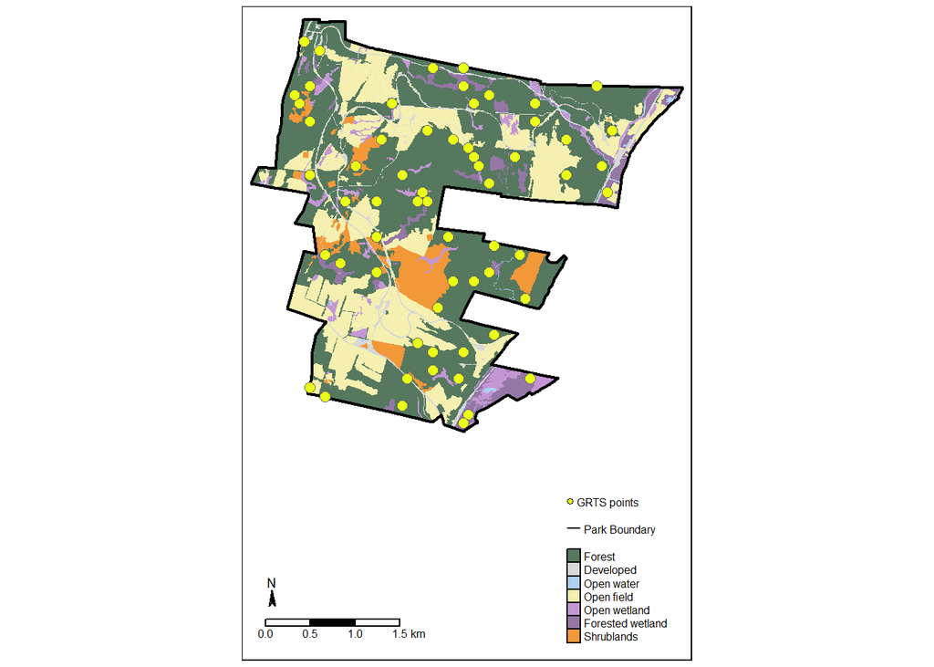

```r
library(tmap)
# Creating list of simp_veg types and their fill colors for easier legend
for_legend <- unique(data.frame(simp_veg = sara_veg$simp_veg, fill_col = sara_veg$fill_col))

sara_map <-
  # Vegetation map
  tm_shape(sara_veg, projection = 26918, bbox = sara_bound) +
  tm_fill("fill_col") +
  tm_add_legend(type = 'fill', labels = for_legend$simp_veg,
                col = for_legend$fill_col, z = 3) +

  # Park boundary
  tm_shape(sara_bound, projection = 26918) +
  tm_borders('black', lwd = 2) +
  tm_add_legend(type = 'line', labels = "Park Boundary", col = "black",
                z = 2)+

  # GRTS points
  tm_shape(grts_forest) +
  tm_symbols(shapes = 21, col = "#EAFF16", border.lwd = 0.5, size = 0.3) +
  tm_add_legend(type = 'symbol', labels = "GRTS points", shape = 21,
                col = "#EAFF16", border.lwd = 0.5, size = 0.3,
                z = 1) +

  # Other map features
  tm_compass(size = 1, type = 'arrow',
             text.size = 0.6, position = c('left', 'bottom')) +
  tm_scale_bar(position = c("left", "bottom")) +
  tm_layout(inner.margins = c(0.35, 0.02, 0.02, 0.02), # make room for legend
            outer.margins = c(0.01, 0.01, 0.01, 0.01),
            legend.text.size = 0.5,
            legend.just = 'right',
            legend.position = c("right", "bottom"))

sara_map
```

**Using leaflet and parktiles**

#### Resources

R Studio’s [leaflet for R](http://rstudio.github.io/leaflet/) page shows the basics of how to use leaflet.

[Geocomputation in R](https://geocompr.robinlovelace.net/) is an excellent online book on the `sf` and `tmap` packages.

### Day 4: Best Practices & Wrap-up

#### Good Coding Practices

Good coding practices - being consistent

DRY principles

#### Control Structures

control structures -if/else

-iteration -for loop - cover for loops in depth -apply family - covered more in depth on day 6 -apply -lapply -purrr - covered more in depth on day 6

-vectorization - examples of vectorized functions -gsub, grep family (avoid regex) -basic vector math -rowsums vs colsums -inequalities ==, <, >, %in% -& , |, (maybe get into &&, || )

-other control structures to be aware of.

#### Troubleshooting Iteration

Troubleshooting and good resources -Troubleshooting iteration -How???? -Simple and complex approaches -in development use verbose iteration -print() to give an update -breakpoints debugging tool in r studio -traceback - certainly an option -should you just ignore warnings()?

-Minimum reproducible examples -Your problem might not be as complex as it seems

### Useful websites

There’s a lot of great online material for learning new applications of R. The ones I’ve used the most are listed below.

Online Books

- [R for Data Science](https://r4ds.had.co.nz/) First author is Hadley Wickham, the programmer behind the tidyverse. There’s a lot of good stuff in here, including a chapter on using R Markdown, which is what I used to generate the website we used for training.
- [ggplot2: Elegant Graphics for Data Analysis](https://ggplot2-book.org//) A great reference on ggplot2 also by Hadley Wickham.
- [Mastering Software Development in R](https://bookdown.org/rdpeng/RProgDA/) First author is Roger Peng, a Biostatistics professors at John Hopkins, who has taught a lot of undergrad/grad students how to use R. He’s also one of the hosts of Not So Standard Deviations podcast. I like his intro to ggplot a lot. He’s also got a lot of more advanced topics in this book, like making functions and packages.
- [R Packages](https://r-pkgs.org/) Another book by Hadley Wickham that teaches you how to build, debug, and test R packages.
- [Advanced R](http://adv-r.had.co.nz/) Yet another book by Hadley Wickham that helps you understand more about how R works under the hood, how it relates to other programming languages, and how to build packages.
- [Mastering Shiny](https://mastering-shiny.org/) And another Hadley Wickham book on building shiny apps.

Other useful sites

- [STAT545](https://stat545.com/index.html) Jenny Bryan’s site that accompanies the graduate level stats class of the same name. I like that she includes topics on best practices for coding, and not just how to make scripts work.
- [RStudio home page](https://rstudio.com/) There’s a ton of info in the Resources tab on this site, including cheatsheets for each package developed by RStudio (ie tidyverse packages), webinars, presentations from past RStudio Conferences, etc.
- [RStudio list of useful R packages by topic](https://support.rstudio.com/hc/en-us/articles/201057987-Quick-list-of-useful-R-packages)
- [Happy Git with R](https://happygitwithr.com/) If you find yourself wanting to go down the path of hosting your code on github, this site will walk you through the process of linking github to RStudio.
- [R-spatial mapping in ggplot](https://www.r-spatial.org/r/2018/10/25/ggplot2-sf.html) The r-spatial.org site is a blog with lots of interesting topics covered. The blog I linked to helped me figure out how to map shapefiles in ggplot.

### Code printout

This tab prints all of the code chunks in this file in one long file.

```r
#--------------------
#       Prep
#--------------------
# By using this hashtag/pound sign, you are telling R to ignore the text afterwards. This is useful for leaving annotation of notes or instructions for yourself, or someone else using your code

# try this line to generate some basic text and become familiar with where results will appear:
print("Hello, lets do some basic math. Results of operations will appear here")

# one plus one
1+1

# two times three, divided by four
(2*3)/4

# basic mathematical and trigonometric functions are fairly similar to what they would be in excel

# calculate the square root of 9
sqrt(9)

# calculate the cube root of 8 (remember that x^(1/n) gives you the nth root of x)
8^(1/3)

# get the cosine of 180 degrees - note that trig functions in R expect angles in radians
# also note that pi is a built-in constant in R
cos(pi)

# calculate 5 to the tenth power
5^10
# the value of 12.098 is assigned to variable 'a'
a <- 12.098

# and the value 65.3475 is assigned to variable 'b'
b <- 65.3475

# we can now perform whatever mathematical operations we want using these two variables without having to repeatedly type out the actual numbers:

a*b

(a^b)/((b+a))

sqrt((a^7)/(b*2))
# read in the data from tree_growth.csv and assign it as a dataframe to the variable "tree_data"
tree_data <- read.csv("data/tree_growth.csv")

# display the 'tree_data' data frame we just created
tree_data
head(tree_data)  # Show the first few lines of the dataframe. Defaults to showing the first 6 rows
head(tree_data, n = 10)  # Show the first 10 rows

summary(tree_data)  # View a basic statistical summary

str(tree_data)  # Get info about the structure of the data

View(tree_data)  # Open a new tab with a spreadsheet view of the data
digits <- 0:9  # Use x:y to create a sequence of integers starting at x and ending at y
digits
is_odd <- rep(c(FALSE, TRUE), 5)  # Use rep(x, n) to create a vector by repeating x n times
is_odd
shoe_sizes <- c(7, 7.5, 8, 8.5, 9, 9.5, 10, 10.5, 11, 11.5)
shoe_sizes
favorite_birds <- c("greater roadrunner", "Costa's hummingbird", "kakapo")
favorite_birds
is.vector(digits)  # Should be TRUE
is.vector(favorite_birds)  # Should also be TRUE

length(digits)  # Hopefully this is 10
length(shoe_sizes)

# Even single values in R are stored as vectors
length_one_chr <- "length one vector"
length_one_int <- 4
is.vector(length_one_chr)
is.vector(length_one_int)
length(length_one_chr)
length(length_one_int)
class(favorite_birds)
class(shoe_sizes)
class(digits)
class(is_odd)
second_favorite_bird <- favorite_birds[2]
second_favorite_bird
top_two_birds <- favorite_birds[c(1,2)]
top_two_birds
odd_digits <- digits[is_odd]
odd_digits
tree_data$Species
tree_data$Age_yr
tree_data[, "Species"]  # Same as tree_data$Species
tree_data[, c("Species", "Age_yr")]  # Data frame with only Species and Age_yr columns
tree_data[1:5, "Species"]  # First five elements of Species column
is.vector(tree_data$Species)
class(tree_data$Species)
is.vector(tree_data$Age_yr)
class(tree_data$Age_yr)

str(tree_data)  # Check out the abbreviations next to the column names: chr, num, and int. These are the data types of the columns.
#to calculate the mean of the 'age' column in the original dataframe:
mean(tree_data$Age_yr)

#or to calculate the mean of the DBH vector we created:
dbh <- tree_data$DBH_in
mean(dbh)

#like-wise for the median, standard deviation, and minimum:
median(tree_data$Age_yr)
sd(tree_data$Age_yr)
min(tree_data$Age_yr)
unique(tree_data$Species)  # in this line, we are printing all of the unique species names in the dataset (in this case 2).
species_names <- unique(tree_data$Species)  # assign unique species names to a variable
in_per_ft <- 12  # Since there are 12 inches in a foot
# here we are specifying the new column on the left side of the '<-', and telling R what we want put into it on the right side of the '<-'.
tree_data$Height_in <- tree_data$Height_ft * in_per_ft

# we can now use the 'head function to check our work, and make sure the proper conversion was carried out:
head(tree_data)
hist(x = tree_data$Age_yr)
# this should generate an ugly but effective scatterplot of tree height vs age. It would appear that older trees are taller!
plot(x = tree_data$Age_yr, y = tree_data$Height_ft)
# let's try the same, but with DBH as the dependent variable on the y axis:
# again, we should see a plot below showing that, even in a make-believe forest, older trees of both species tend to be thicker!
plot(x = tree_data$Age_yr, y = tree_data$DBH_in)
?plot
?dplyr::filter
install.packages("janitor")
library('janitor')
library('janitor')
install.packages("tidyverse")
library('tidyverse')
library('janitor')
library('tidyverse')
messy_data <- tibble(TrailName = c('Bayside', 'Coastal', 'Tidepools',
                                   'Monument', 'Tidepools', NA),
                     Visitor_count = c(200, 300, 400, 500, 400, NA),
                     `empty row` = NA)
messy_data
clean_data <- clean_names(messy_data)
clean_data
remove_empty(
  # first argument is the data
  dat,
  # the next specifies if you want to get rid of empty rows, columns, or both
  which = c("rows", "cols"),
  # this last one asks whether (TRUE) or not (FALSE) you want R to tell you which rows or columns were removed
  quiet = TRUE)
clean_data2 <- remove_empty(clean_data, which = c('rows'), quiet = FALSE)
clean_data2
clean_data2 <- remove_empty(clean_data, which = c('rows', 'cols'), quiet = TRUE)
clean_data2
clean_data <- clean_names(messy_data)
clean_data <- remove_empty(clean_data, which = c('rows', 'cols'), quiet = TRUE)
clean_data
clean_data <- clean_names(messy_data) %>%
              remove_empty(which = c('rows', 'cols'), quiet = TRUE)
clean_data
# note that replacing %>% with |> also works
clean_data <- clean_names(messy_data) %>%
              remove_empty(which = c('rows', 'cols'), quiet = TRUE) %>%
              distinct()
clean_data
messy_data2 <- tibble(`Park Code` = c(NA, NA, 'CABR', 'CHIS', 'SAMO', 'SAMO'),
                     visitor_count = c(NA, NA, 400, 500, 400, 400),
                     `empty row` = NA)
clean_data2 <- clean_names(messy_data2) %>%
               remove_empty(which = c('rows', 'cols'), quiet = TRUE) %>%
               distinct()
library('readr')
library('janitor')
library('tidyverse')
park_visits <- read_csv("https://raw.githubusercontent.com/rfordatascience/tidytuesday/master/data/2019/2019-09-17/national_parks.csv")
state_pop <- read_csv("https://raw.githubusercontent.com/rfordatascience/tidytuesday/master/data/2019/2019-09-17/state_pop.csv")
gas_price <- read_csv("https://raw.githubusercontent.com/rfordatascience/tidytuesday/master/data/2019/2019-09-17/gas_price.csv")
# let's see the column names in park_visits
colnames(park_visits)
```

```r
# we can also look at the first few rows by using head()

head(park_visits)

# you can either select for the columns you want
park_visits1 <- park_visits %>% select(year, parkname, unit_code, state, visitors)

# or against the columns you don't want, by using the minus sign before the column name
park_visits2 <- park_visits %>% select(-gnis_id, -geometry, -metadata, -number_of_records, -region, -unit_name, -unit_type)

# you can check if you have the same result by using colnames()
colnames(park_visits1)
colnames(park_visits2)

# to clear up our environment, we'll get rid of park_visits1 and 2 using remove()
remove(park_visits1, park_visits2)

# since we won't need all of the columns in park_visits, we'll change that file (note that park_visits is on both the left and right sides of the pipe)
park_visits <- park_visits %>% select(year, parkname, unit_code, state, visitors)
# rename parkname column to make it snake case
park_visits <- park_visits %>% rename(park_name = parkname)

# we can check if we've done it correctly by looking at the column names
colnames(park_visits)
wa_park_visits <- filter(
                        # name of data.frame
                        park_visits,
                        # condition
                        state == 'WA'
                        )

# head() shows the first few rows of data
head(wa_park_visits)

# you can use the unique() to check you've done the filtering correctly
unique(wa_park_visits$state)
wa_park_visits <- park_visits %>%
                  # filter for parks in WA
                  filter(state == 'WA' &
                  # filter for total visitation
                  year == 'Total' &
                  # filter for over 5 million visitors
                  visitors > 5000000)

# head() shows the first few rows of data
head(wa_park_visits)
pr_park_visits <- park_visits %>%
                  # filter for parks in Puerto Rico
                  filter(state == 'PR' &
                  # filter for total visitation
                  year == 'Total')

# head() shows the first few rows of data
head(pr_park_visits)
# San Juan National Historic Site (Puerto Rico) had > 55 million visitors!

# remove result from environment
remove(pr_park_visits)
wa_park_visits <- park_visits %>%
                  # filter for parks in WA
                  filter(state == 'WA' &
                  # filter for total visitation
                  year == 'Total' &
                  # filter for over 5 million visitors
                  visitors > 5000000) %>%
                  # arrange by visitation - default is ascending order
                  arrange(visitors)

# look at result (df is short so head() not needed)
wa_park_visits

# to arrange by descending order, we can use desc()
wa_park_visits2 <- wa_park_visits %>%
                  arrange(desc(visitors))

# look at result
wa_park_visits2

# remove one result
remove(wa_park_visits2)
# two ways to get the number of observations per state

# option 1 - use pull() to isolate a column and table() to get # of observations
state_n <- park_visits %>%
           # pull the state column only
           pull(state) %>%
           # get # of observations by state in table output
           table()

# option 2 - use group_by() to isolate column(s) and tally() to get # of obs
state_n2 <- park_visits %>%
           # group by state
           group_by(state) %>%
           # get tally of observations by state in output
           tally()

# remove created objects
remove(state_n, state_n2)
wa_park_visits_millions <- wa_park_visits %>%
                           mutate(visitors_mil = visitors/1000000)

wa_park_visits_millions
park_visits2 <- park_visits %>%
                # remove the rows with Totals per park
                filter(year != "Total")  %>%
                # do calculations by park
                group_by(park_name) %>%
                # add visit_percent column
                # visits fore each year divided by the sum of total visits for each park
                # the na.rm = TRUE means that NA values are not included in calculations
                # round(2) is rounds result to 2 decimal places for easier reading
                mutate(visit_percent = (100*visitors/sum(visitors, na.rm = TRUE)) %>%
                         round(2))

# take a look at the result
head(park_visits2)

# remove from environment
remove(park_visits2)
state_summary <- park_visits %>%
                # filter for total visitation numbers (to avoid double counts)
                filter(year == 'Total') %>%
                # do calculations by state
                group_by(state) %>%
                # calculate summaries
                summarize(
                  # mean number of total visitors across parks in each state
                  mean_visit = mean(visitors, na.rm = TRUE),
                  # sd of total visitors across parks in each state
                  sd_visit = sd(visitors, na.rm = TRUE),
                  # min total visitors across parks in each state
                  min_visit = min(visitors, na.rm = TRUE),
                  # max total visitors across parks in each state
                  max_visit = max(visitors, na.rm = TRUE),
                  # get number of park units w data in each state
                  n_parks = n()
                )

# take a look at the result
head(state_summary)

# if you want to continue analyzing this summarized data, you must first ungroup()
# for example:
state_summary <- state_summary %>%
                 ungroup() %>%
                 mutate(dif = max_visit - min_visit)

# remove from environment
remove(state_summary)
challenge2 <- park_visits %>%
                # filter for total visitation numbers (to avoid double counts)
                filter(year == 'Total') %>%
                # do calculations by state
                group_by(state) %>%
                # calculate summaries
                summarize(
                  # mean number of total visitors across parks in each state
                  mean_visit = mean(visitors, na.rm = TRUE),
                  # get number of park units w data in each state
                  n_parks = n()
                ) %>%
                # ungroup to do another calculation
                ungroup() %>%
                # calculate visit/n
                mutate(visit_per_park = mean_visit/n_parks) %>%
                # select relevant columns
                select(state, visit_per_park) %>%
                # arrange in descending order
                arrange(desc(visit_per_park))
```

```r
# take a look at the result
head(challenge2)

# remove from environment
remove(challenge2)
# call packages
library('readr')
library('janitor')
library('tidyverse')

# get data
park_visits <- read_csv("https://raw.githubusercontent.com/rfordatascience/tidytuesday/master/data/2019/2019-09-17/national_parks.csv")
state_pop <- read_csv("https://raw.githubusercontent.com/rfordatascience/tidytuesday/master/data/2019/2019-09-17/state_pop.csv")
gas_price <- read_csv("https://raw.githubusercontent.com/rfordatascience/tidytuesday/master/data/2019/2019-09-17/gas_price.csv")

# cut some columns from park_visits data
park_visits <- park_visits %>% select(year, parkname, unit_code, state, visitors)

# we'll first take a subset of the park visits data
medn_visits <- park_visits %>%
               # get parks in MEDN and no totals, years 2010-2015
               filter(unit_code %in% c('CABR', 'CHIS', 'SAMO') & year != 'Total') %>%
               # make year a number, since no more text
               mutate(year = as.numeric(year)) %>%
               # get years 2010:2015
               filter(year >= 2010 & year <=2015) %>%
               # arrange in ascending order
               arrange(year) %>%
               # select relevant columns
               select(unit_code, year, visitors)

# if we take a look at the data, it is in long format, each observation is a row
# this isn't the most human-friendly way to look at data, but it is really helpful if we want to use dplyr group_by() functions like mutate() and summarize()
medn_visits

# conversely, we can pivot longer to make the data wide format
# it is more human-friendly but you can't use dplyr functions on it easily
medn_visits_wide <- pivot_wider(medn_visits, names_from = year, values_from = visitors)
medn_visits_wide
# check out the original data (medn_visits) in long format
medn_visits

# if we want to make each row a park and each column a year, we can pivot wider
medn_visits_wide <- medn_visits %>%
                    pivot_wider(
                                # names from is the thing you want to be the columns
                                names_from = year,
                                # values from is what you want to fill the columns with
                                values_from = visitors)

# check out the result
medn_visits_wide

# we can also make park units the columns and fill it with visitor data for each year
medn_visits_wide <- medn_visits %>%
                    pivot_wider(names_from = unit_code, values_from = visitors)
medn_visits_wide
# check out the original data (medn_visits_wide) in wide format
medn_visits_wide

# if we want to make each row an observation, with an associated park and year, we'll pivot_longer
medn_visits_long <- medn_visits_wide %>%
                    pivot_longer(
                                # first argument is the columns you'd like to transform
                                SAMO:CHIS,
                                # next is what you'd like to name the former name cols
                                names_to = 'unit_code',
                                # last is what you'd like to name the former values cols
                                values_to = 'visitors')

# check out the result
medn_visits_long

# this should look familiar - like the original medn_visits data
# get 3 states of choice (FL, CA, AK) for years 2010-2015
solution_original <- state_pop %>%
                     filter(state %in% c('FL', 'AK', 'CA') &
                            year >= 2010 & year <= 2015)
# pivot wider
solution_wide <- solution_original %>%
                 pivot_wider(names_from = 'year',
                             values_from = 'pop')

# pivot longer to return to format of solution_original
solution_long <- solution_wide %>%
                 pivot_longer(`2010`:`2015`, names_to = 'year', values_to = 'pop')
# call packages
library('readr')
library('janitor')
library('tidyverse')

# get data
park_visits <- read_csv("https://raw.githubusercontent.com/rfordatascience/tidytuesday/master/data/2019/2019-09-17/national_parks.csv")
state_pop <- read_csv("https://raw.githubusercontent.com/rfordatascience/tidytuesday/master/data/2019/2019-09-17/state_pop.csv")
gas_price <- read_csv("https://raw.githubusercontent.com/rfordatascience/tidytuesday/master/data/2019/2019-09-17/gas_price.csv")

# cut some columns from park_visits data and make sure year is nuemric data only
park_visits <- park_visits %>% select(year, parkname, unit_code, state, visitors) %>%
  filter(year!="Total") %>% mutate(year=as.integer(year))

# we'll first make two subsets of the park_visits data
SHEN_visits <- park_visits %>%
               # get data from Shenandoah.
               filter(unit_code == 'SHEN')

SHEN_visits

ACAD_visits <- park_visits %>%
               # get data from Acadia.
               filter(unit_code == 'ACAD')

ACAD_visits

# now we will combine the 2 data.frames into one.
SHEN_ACAD_visits <- bind_rows(SHEN_visits, ACAD_visits)

# check that data from both parks is there
SHEN_ACAD_visits %>% pull(unit_code) %>% table

rm(SHEN_ACAD_visits, SHEN_visits, ACAD_visits)

# we'll first make two subsets of the park_visits data
visits_left <- park_visits %>%
               # get first 2 columns.
               select(year, parkname)

visits_left

visits_right <- park_visits %>%
               #  get last 3 columns.
               select(unit_code, state, visitors)

visits_right

visits_bound<-bind_cols(visits_left, visits_right)

visits_bound

rm(visits_left, visits_right, visits_bound)

# Atlantic islands
Atlantic <- park_visits %>%
                     filter(state %in% c('PR', 'VI'))
# Pacific Islands
Pacific <- park_visits %>%
                     filter(state %in% c('AS', 'GU', 'HI'))

# All islands
Islands <- bind_rows(Atlantic, Pacific)


rm(Atlantic, Pacific, Islands)

# filter the state data
state_pop2<-state_pop %>% filter(year<2000)

# left_join example
state_pop_gas1 <-left_join(
  x=state_pop2,   #first data.frame
  y=gas_price,  # second data.frame
  by="year"  # key column
)
```

```r
state_pop_gas1

# left_join example
state_pop_gas2 <-right_join(
  x=state_pop2,   #first data.frame
  y=gas_price,  # second data.frame
  by="year"  # key column
)

state_pop_gas2

# inner_join example

state_pop_gas3 <-inner_join(
  x=state_pop2,   #first data.frame
  y=gas_price,  # second data.frame
  by="year"  # key column
)

state_pop_gas3

# full_join example

state_pop_gas4 <-full_join(
  x=state_pop2,   #first data.frame
  y=gas_price,  # second data.frame
  by="year"  # key column
)

state_pop_gas4

rm(state_pop_gas1, state_pop_gas2, state_pop_gas3, state_pop_gas4)


park_visits_pop<-left_join(park_visits, state_pop, by=c("state", "year"))

rm(park_visits_pop)

# semi_join example

state_pop_gas5 <-semi_join(
  x=state_pop2,   #first data.frame
  y=gas_price,  # second data.frame
  by="year"  # key column
)

state_pop_gas5

# semi_join example

state_pop_gas6 <-anti_join(
  x=state_pop2,   #first data.frame
  y=gas_price,  # second data.frame
  by="year"  # key column
)

state_pop_gas6

#clean up
rm(state_pop2, state_pop_gas1, state_pop_gas2, state_pop_gas3, state_pop_gas4, state_pop_gas5, state_pop_gas6)


## In this case we filter out the NA values in the semi_join function. You could also fliter them our first and save that to a new data.frame and then do the join.

park_visits_filtered<-semi_join(park_visits, state_pop %>% filter(!is.na(pop)), by=c("state", "year")) %>%
  semi_join(gas_price, by="year")

park_visits_filtered


rm(park_visits_filtered)
#install.packages(c("sf", "spsurvey"))
library(dplyr) # for filter, select, mutate and %>%
library(sf)
library(tmap)
library(spsurvey)
# Read in shapefiles from teams data folder
sara_bound1 <- st_read("./shapefiles/SARA_boundary_4269.shp")
sara_veg1 <- st_read("./shapefiles/SARA_Veg.shp")

# Check that the projections match; fix the one that doesn't match
st_crs(sara_bound1) == st_crs(sara_veg1) # FALSE- projections don't match.
# sara_bound1 needs to be reprojected to UTM Zone 18N NAD83.
sara_bound <- st_transform(sara_bound1, crs = 26918)
st_crs(sara_bound) == st_crs(sara_veg1) # TRUE

# Quick plot
plot(sara_bound[1])
plot(sara_veg1[1]) # bigger extent than boundary

# Intersect boundary and veg to be same extend
sara_veg <- st_intersection(sara_veg1, sara_bound)
plot(sara_veg[1])
# View attribute table of layers
head(sara_bound) # 1 feature with 95 fields

str(sara_veg)
head(sara_veg)
names(sara_veg)
table(sara_veg$ANDERSONII)

# Simplify vegetation types for easier plotting
dev <- c("1. Urban or Built-up Land", "11. Residential",
         "12. Commercial and Services", "13. Industrial",
         "14. Transportation, Communications, and Utilities",
         "17. Other Urban or Built-up Land")
crop <- c("21. Cropland and Pasture",
          "22. Orchards, Groves, Vineyards, and Nurseries",
          "31. Herbaceous Rangeland")
shrubland <- c("32. Shrub and Brush Rangeland")
forest_up <- c("41. Deciduous Forest Land", "42. Evergreen Forest Land",
               "43. Mixed Forest Land")
forest_wet <- c("61. Forested Wetland")
open_wet <- c("62. Nonforested wetland", "62. Nonforested Wetland")
water <- c("5. Water", "51. Streams and Canals", "53. Reservoirs")
unk <- "Unclassified"

# Create 2 fields in the veg attribute table: simp_veg, and fills
sara_veg <- sara_veg %>%
  mutate(simp_veg = case_when(ANDERSONII %in% dev ~ "Developed",
                              ANDERSONII %in% crop ~ "Open field",
                              ANDERSONII %in% shrubland ~ "Shrublands",
                              ANDERSONII %in% forest_up ~ "Forest",
                              ANDERSONII %in% forest_wet ~ "Forested wetland",
                              ANDERSONII %in% open_wet ~ "Open wetland",
                              ANDERSONII %in% water ~ "Open water",
                              ANDERSONII %in% unk ~ "Unclassified",
                              TRUE ~ "Unknown"),
         fill_col = case_when(simp_veg == "Developed" ~ "#D8D8D8",
                              simp_veg == "Open field" ~ "#f5f0b0",
                              simp_veg == "Shrublands" ~ "#F29839",
                              simp_veg == "Powerline ROW" ~ "#F9421D",
                              simp_veg == "Forest" ~ "#55785e",
                              simp_veg == "Forested wetland" ~ "#9577a6",
                              simp_veg == "Open wetland" ~ "#c497d4",
                              simp_veg == "Open water" ~ "#AFD0F2",
                              simp_veg == "Unclassified" ~ "#ffffff"))

# generate random sample
  #sample(1:100000, 1) #62051
set.seed(62051)
sara_grts <- grts(sara_bound, n_base = 100) # generate 100 points within SARA boundary
sara_grts$sites_base$priority <- as.numeric(row.names(sara_grts$sites_base)) # add priority number (same as row.name)
# Spatial join
grts_veg <- st_join(sara_grts$sites_base, sara_veg %>% select(ANDERSONII))

# Create list of forest habitats
sort(unique(sara_veg$ANDERSONII))
forest_veg <- c("41. Deciduous Forest Land", "42. Evergreen Forest Land",
                "43. Mixed Forest Land", "61. Forested Wetland")

# Filter out non-forest points
grts_forest <- grts_veg %>% filter(ANDERSONII %in% forest_veg)
nrow(grts_veg) # 100 points
nrow(grts_forest) # fewer points
library(tmap)
# Creating list of simp_veg types and their fill colors for easier legend
for_legend <- unique(data.frame(simp_veg = sara_veg$simp_veg, fill_col = sara_veg$fill_col))

sara_map <-
  # Vegetation map
  tm_shape(sara_veg, projection = 26918, bbox = sara_bound) +
  tm_fill("fill_col") +
  tm_add_legend(type = 'fill', labels = for_legend$simp_veg,
                col = for_legend$fill_col, z = 3) +

  # Park boundary
  tm_shape(sara_bound, projection = 26918) +
  tm_borders('black', lwd = 2) +
  tm_add_legend(type = 'line', labels = "Park Boundary", col = "black",
                z = 2)+

  # GRTS points
  tm_shape(grts_forest) +
  tm_symbols(shapes = 21, col = "#EAFF16", border.lwd = 0.5, size = 0.3) +
  tm_add_legend(type = 'symbol', labels = "GRTS points", shape = 21,
                col = "#EAFF16", border.lwd = 0.5, size = 0.3,
                z = 1) +
```

```r
  # Other map features
  tm_compass(size = 1, type = 'arrow',
             text.size = 0.6, position = c('left', 'bottom')) +
  tm_scale_bar(position = c("left", "bottom")) +
  tm_layout(inner.margins = c(0.35, 0.02, 0.02, 0.02), # make room for legend
            outer.margins = c(0.01, 0.01, 0.01, 0.01),
            legend.text.size = 0.5,
            legend.just = 'right',
            legend.position = c("right", "bottom"))

sara_map
sara_map
```

### Meet the Instructors

We are the people who designed and led the training for this week. We hope you found it useful, and that you keep with it!

**Andrew Birch**  
WRD/IMD Water Quality Program Lead  
andrew_birch@nps.gov

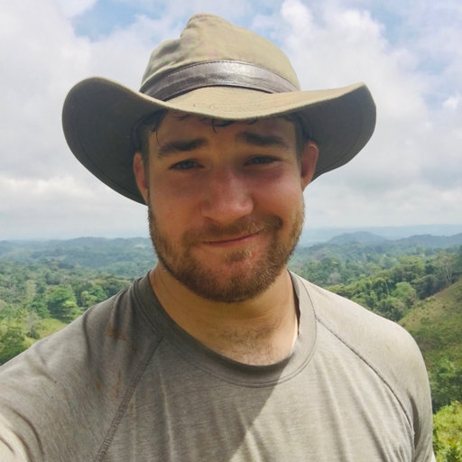

**Ellen Cheng**  
SER Quantitative Ecologist  
ellen_cheng@nps.gov

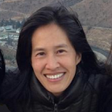

**Kate Miller**  
NETN/MIDN Quantitative Ecologist  
kathryn_miller@nps.gov

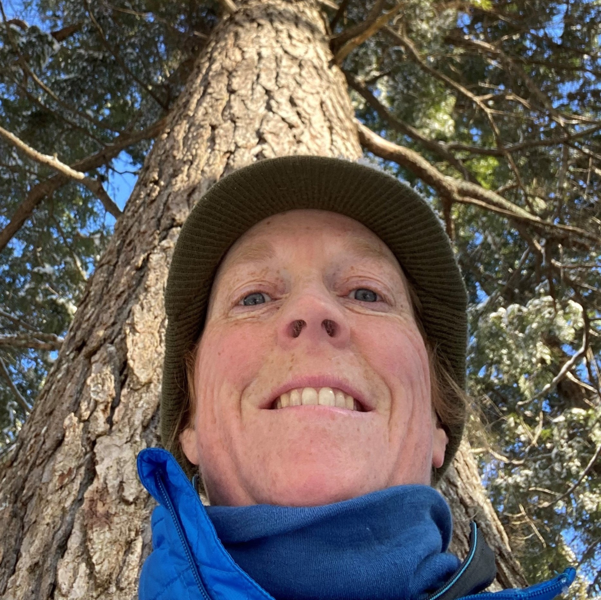

**Lauren Pandori**  
CABR Marine Biologist - MEDN  
lauren_pandori@nps.gov

[figure not shown]

**Thomas Parr**  
GLKN Program Manager  
thomas_parr@nps.gov

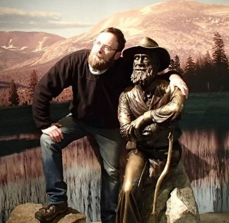

**John Paul Schmit**  
NCRN Quantitative Ecologist  
john_paul_schmit@nps.gov

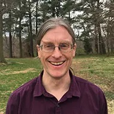

**Sarah Wright**  
MOJN Data Scientist  
sarah_wright@nps.gov

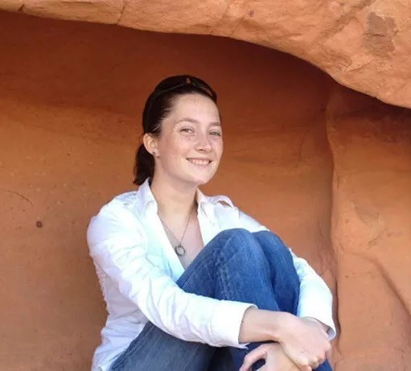